# modelin_forDSM_RANst

gaohong

2019年7月13日

# 设置工作路径，加载包

```r
library(rgdal)
library(raster)
library(randomForest)
```

# 构建环境因子图层

```r
setwd("E:/soilPaper/modling/EnFactor")

files<-c("DEM.tif","Slope.tif","PlanC.tif","ProfileC.tif","TWI.tif","Bedrock.tif","LSF.tif","VD.tif","RSP.tif")

covStack <- raster(files[1])
for (i in 2:length(files)) {
  covStack <- stack(covStack, files[i])
}

#设置读取样点数据路径
point_shp_folder="E:/soilPaper/modling/allTrainingSamples_shp/"

#设置最终结果tif的保存路径
result_tif_folder="E:/soilPaper/modling/result_mapTif/"

##设置随机数种子
set.seed(2019)

soil_type<-c(1,3,7,20,21,23,30,31,501,502,503)  # 41样本数量太少，删掉。
sampleNum_dict<-list()
```

# DEM -ok

## ns3

RANst DEM ns3 15

```r
mn="All_pRANst_DEM_NS3_pen15"

shpPoint<-readOGR(paste(point_shp_folder,mn,".shp",sep = "")) ###
sampData <- extract(covStack, shpPoint, sp = TRUE,method = "simple")

sampData<-sampData@data

sampData<-sampData[sampData$soilID %in% soil_type,]

sampData<-na.omit(sampData)

print(dim(sampData))
```

```
## [1] 1042   10
```

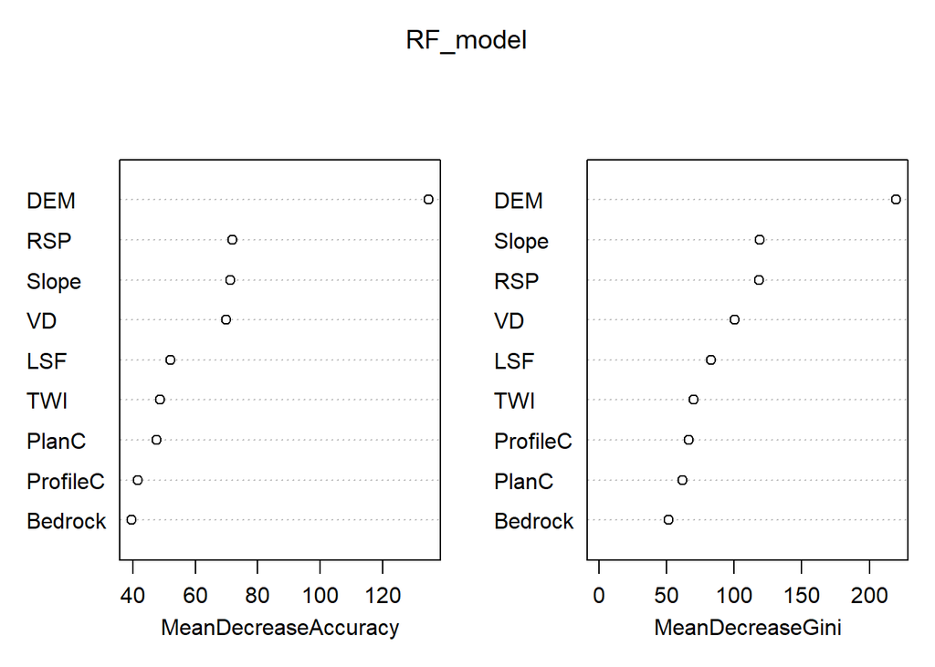

```r
sampleNum_dict[mn]<-nrow(sampData)

sampData$Bedrock<- droplevels(as.factor(sampData$Bedrock))
sampData$soilID<- droplevels(as.factor(sampData$soilID))

RF_model<-randomForest(soilID ~.,data = sampData,
                       importance = TRUE, proximity = FALSE,
                       ntree=1000,type="classification")

varImpPlot(RF_model)
```

```r
print(RF_model)
```

```
##
## Call:
##  randomForest(formula = soilID ~ ., data = sampData, importance = TRUE,      proximity = FALSE, ntree = 1000, type = "classification")
##                Type of random forest: classification
##                      Number of trees: 1000
## No. of variables tried at each split: 3
##
##         OOB estimate of  error rate: 27.54%
## Confusion matrix:
##     1 20 21 23  3 30 31 501 502 503   7 class.error
## 1   3  0  0  0  3  0  0   0   0   0   0   0.5000000
## 20  0 98 16  1  0  0  0   2   2  27  14   0.3875000
## 21  0 32 25  0  0  0  0   0   0   3   0   0.5833333
## 23  0  0  0 64  0 11  5   0   0  18   4   0.3725490
## 3   4  0  0  0 35  0  0  16   0   0   0   0.3636364
## 30  0  0  0  8  0 21  1   0   0   1   2   0.3636364
## 31  0  0  0  6  0  0 34   0   0   0   0   0.1500000
## 501 0  3  0  0 11  0  0 146   1   0  11   0.1511628
## 502 0  2  0  0  0  0  0   2  13   2   3   0.4090909
## 503 0 18  2 15  0  1  1   0   1 201   7   0.1829268
## 7   0  8  0  2  0  2  0  11   1   7 115   0.2123288
```

```r
map_RF <- predict(covStack, RF_model, paste(result_tif_folder,mn,".tif",sep=""),
                  format = "GTiff", datatype = "FLT4S", overwrite = TRUE)

rm("mn","shpPoint","sampData","RF_model","map_RF")
```

RANst DEM ns3 30

```r
mn="All_pRANst_DEM_NS3_pen30"

shpPoint<-readOGR(paste(point_shp_folder,mn,".shp",sep = "")) ###
sampData <- extract(covStack, shpPoint, sp = TRUE,method = "simple")

sampData<-sampData@data

sampData<-sampData[sampData$soilID %in% soil_type,]

sampData<-na.omit(sampData)

print(dim(sampData))
```

```
## [1] 2043   10
```

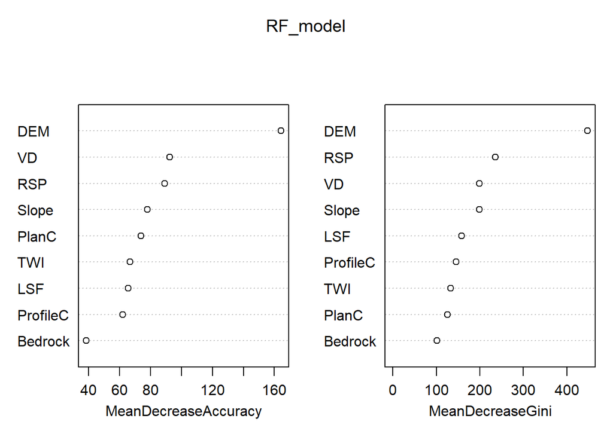

```r
sampleNum_dict[mn]<-nrow(sampData)

sampData$Bedrock<- droplevels(as.factor(sampData$Bedrock))
sampData$soilID<- droplevels(as.factor(sampData$soilID))

RF_model<-randomForest(soilID ~.,data = sampData,
                       importance = TRUE, proximity = FALSE,
                       ntree=1000,type="classification")

varImpPlot(RF_model)
```

```r
print(RF_model)
```

```
##
## Call:
##  randomForest(formula = soilID ~ ., data = sampData, importance = TRUE,      proximity = FALSE, ntree = 1000, type = "classification")
##                Type of random forest: classification
##                      Number of trees: 1000
## No. of variables tried at each split: 3
##
##         OOB estimate of  error rate: 26.28%
## Confusion matrix:
##      1  20 21  23  3 30 31 501 502 503   7 class.error
## 1   10   0  0   0  3  0  0   0   0   0   0   0.2307692
## 20   0 191 26   1  0  0  0   5   2  59  29   0.3897764
## 21   0  38 61   0  0  0  0   2   1   7   4   0.4601770
## 23   0   1  0 125  0 16 11   0   0  34   7   0.3556701
## 3    2   0  0   0 79  0  0  29   0   0   0   0.2818182
## 30   0   0  0  14  0 35  7   0   0   3   4   0.4444444
## 31   0   0  0  18  0  6 55   0   0   0   0   0.3037975
## 501  0   2  0   0 24  0  0 302   1   0  13   0.1169591
## 502  0   7  0   0  0  0  0   2  31   0   1   0.2439024
## 503  0  44  4  26  0  2  0   0   0 406   6   0.1680328
## 7    0  25  1   2  0  6  0  21   2  19 211   0.2648084
```

```r
map_RF <- predict(covStack, RF_model, paste(result_tif_folder,mn,".tif",sep=""),
                  format = "GTiff", datatype = "FLT4S", overwrite = TRUE)

rm("mn","shpPoint","sampData","RF_model","map_RF")
```

RANst DEM ns3 45

```r
mn="All_pRANst_DEM_NS3_pen45"

shpPoint<-readOGR(paste(point_shp_folder,mn,".shp",sep = "")) ###
sampData <- extract(covStack, shpPoint, sp = TRUE,method = "simple")

sampData<-sampData@data

sampData<-sampData[sampData$soilID %in% soil_type,]

sampData<-na.omit(sampData)

print(dim(sampData))
```

```
## [1] 3038   10
```

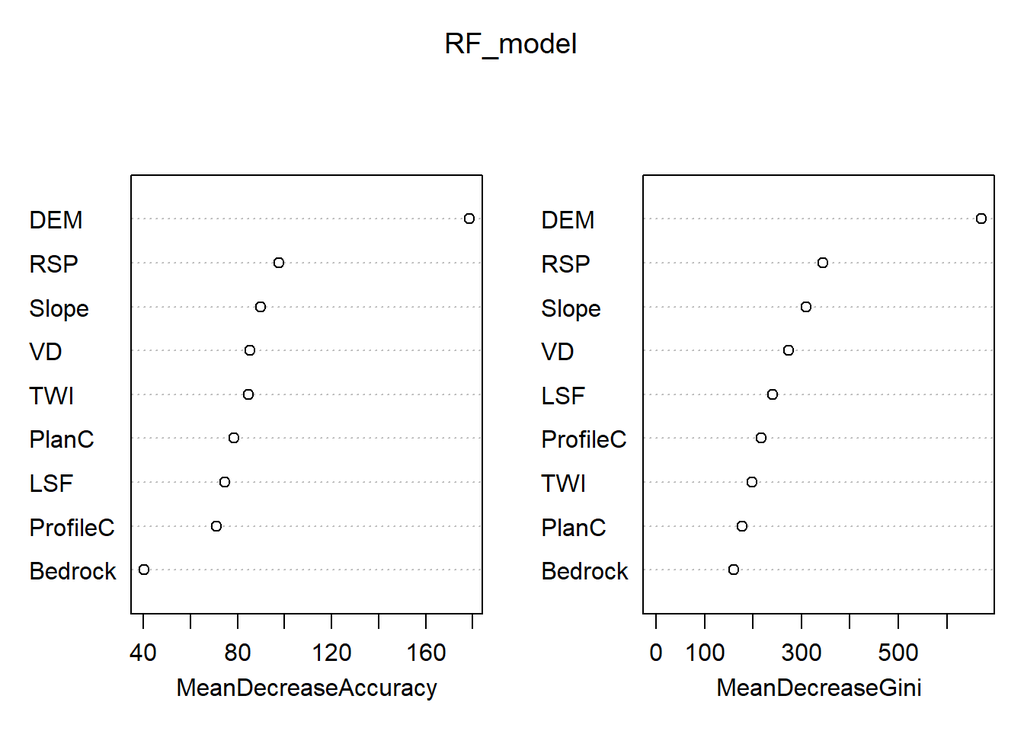

```r
sampleNum_dict[mn]<-nrow(sampData)

sampData$Bedrock<- droplevels(as.factor(sampData$Bedrock))
sampData$soilID<- droplevels(as.factor(sampData$soilID))

RF_model<-randomForest(soilID ~.,data = sampData,
                       importance = TRUE, proximity = FALSE,
                       ntree=1000,type="classification")

varImpPlot(RF_model)
```

```r
print(RF_model)
```

```
##
## Call:
##  randomForest(formula = soilID ~ ., data = sampData, importance = TRUE,      proximity = FALSE, ntree = 1000, type = "classification")
##                Type of random forest: classification
##                      Number of trees: 1000
## No. of variables tried at each split: 3
##
##         OOB estimate of  error rate: 25.67%
## Confusion matrix:
##      1  20 21  23   3 30 31 501 502 503   7 class.error
## 1   14   0  0   0   4  0  0   0   0   0   0   0.2222222
## 20   0 290 38   1   0  0  0   6   1  88  40   0.3750000
## 21   0  64 81   0   0  0  0   1   3  17   1   0.5149701
## 23   0   0  0 188   0 18 10   0   0  59  12   0.3449477
## 3    4   0  0   0 122  0  0  38   0   0   0   0.2560976
## 30   0   0  0  20   0 59  6   0   0   1   6   0.3586957
## 31   0   0  0  23   0  9 83   0   0   3   0   0.2966102
## 501  0   5  0   0  36  0  0 451   1   0  20   0.1208577
## 502  0   3  1   0   0  0  0   1  49   2   5   0.1967213
## 503  0  68  4  44   0  1  0   0   0 590  20   0.1884457
## 7    0  39  1   3   0  3  0  24   5  21 331   0.2248244
```

```r
map_RF <- predict(covStack, RF_model, paste(result_tif_folder,mn,".tif",sep=""),
                  format = "GTiff", datatype = "FLT4S", overwrite = TRUE)

rm("mn","shpPoint","sampData","RF_model","map_RF")
```

## ns5

RANst DEM ns5 15

```r
mn="All_pRANst_DEM_NS5_pen15"

shpPoint<-readOGR(paste(point_shp_folder,mn,".shp",sep = "")) ###
sampData <- extract(covStack, shpPoint, sp = TRUE,method = "simple")

sampData<-sampData@data

sampData<-sampData[sampData$soilID %in% soil_type,]

sampData<-na.omit(sampData)

print(dim(sampData))
```

```
## [1] 355  10
```

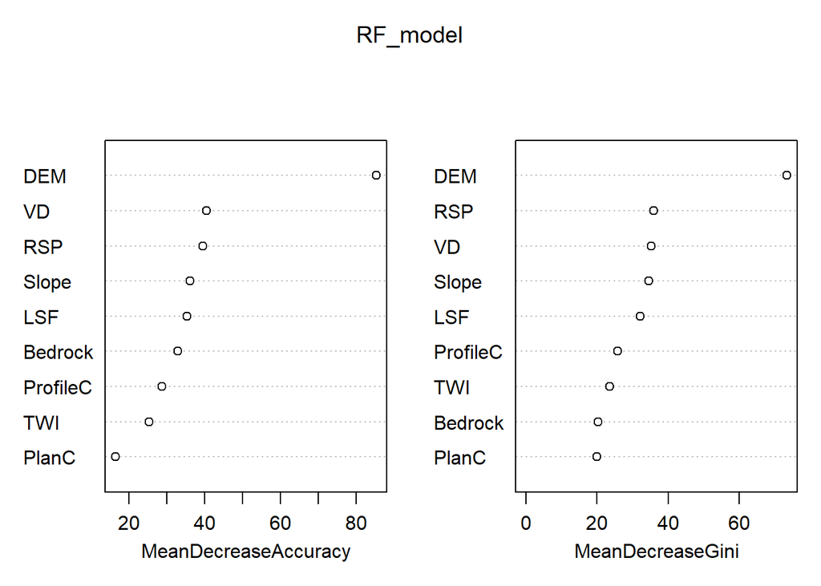

```r
sampleNum_dict[mn]<-nrow(sampData)

sampData$Bedrock<- droplevels(as.factor(sampData$Bedrock))
sampData$soilID<- droplevels(as.factor(sampData$soilID))

RF_model<-randomForest(soilID ~.,data = sampData,
                       importance = TRUE, proximity = FALSE,
                       ntree=1000,type="classification")

varImpPlot(RF_model)
```

```r
print(RF_model)
```

```
##
## Call:
##  randomForest(formula = soilID ~ ., data = sampData, importance = TRUE,      proximity = FALSE, ntree = 1000, type = "classification")
##                Type of random forest: classification
##                      Number of trees: 1000
## No. of variables tried at each split: 3
##
##         OOB estimate of  error rate: 34.65%
## Confusion matrix:
##     1 20 21 23  3 30 31 501 502 503  7 class.error
## 1   0  0  0  0  1  0  0   0   0   0  0   1.0000000
## 20  0 24  5  0  0  0  0   1   0  12  6   0.5000000
## 21  0  9 11  0  0  0  0   1   0   1  0   0.5000000
## 23  0  0  0 13  0  2  4   0   0   9  2   0.5666667
## 3   0  0  0  0 11  0  0   9   0   0  0   0.4500000
## 30  0  0  0  5  0  0  0   0   0   1  2   1.0000000
## 31  0  0  0  2  0  1 10   0   0   0  0   0.2307692
## 501 0  0  0  0  4  0  0  57   1   0  4   0.1363636
## 502 0  2  0  0  0  0  0   2   3   0  1   0.6250000
## 503 0  4  1  4  0  0  0   0   0  71  6   0.1744186
## 7   0  6  0  1  0  1  0   3   1   9 32   0.3962264
```

```r
map_RF <- predict(covStack, RF_model, paste(result_tif_folder,mn,".tif",sep=""),
                  format = "GTiff", datatype = "FLT4S", overwrite = TRUE)

rm("mn","shpPoint","sampData","RF_model","map_RF")
```

RANst DEM ns5 30

```r
mn="All_pRANst_DEM_NS5_pen30"

shpPoint<-readOGR(paste(point_shp_folder,mn,".shp",sep = "")) ###
sampData <- extract(covStack, shpPoint, sp = TRUE,method = "simple")

sampData<-sampData@data

sampData<-sampData[sampData$soilID %in% soil_type,]

sampData<-na.omit(sampData)

print(dim(sampData))
```

```
## [1] 679  10
```

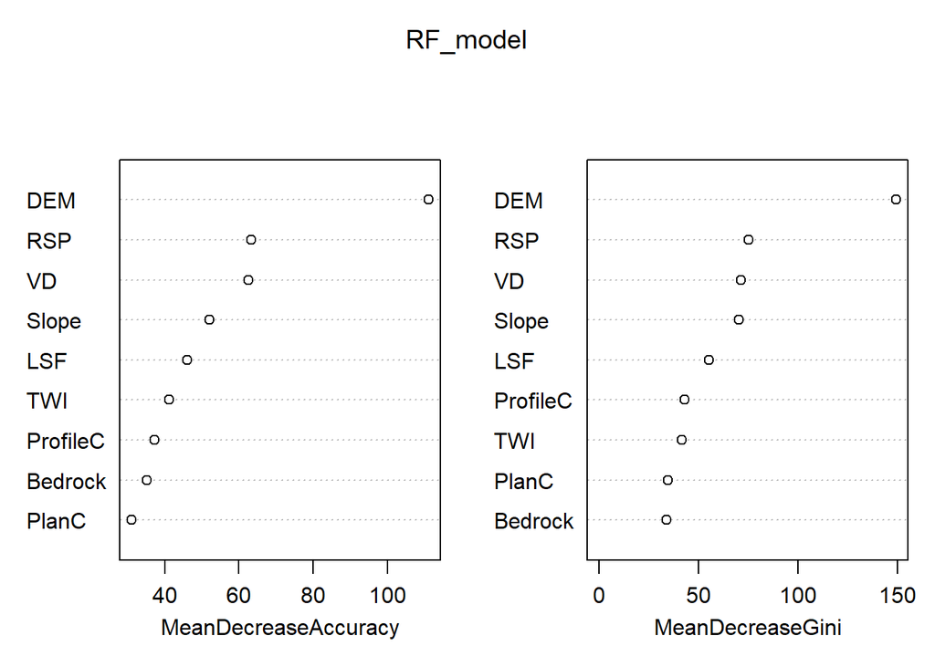

```r
sampleNum_dict[mn]<-nrow(sampData)

sampData$Bedrock<- droplevels(as.factor(sampData$Bedrock))
sampData$soilID<- droplevels(as.factor(sampData$soilID))

RF_model<-randomForest(soilID ~.,data = sampData,
                       importance = TRUE, proximity = FALSE,
                       ntree=1000,type="classification")

varImpPlot(RF_model)
```

```r
print(RF_model)
```

```
##
## Call:
##  randomForest(formula = soilID ~ ., data = sampData, importance = TRUE,      proximity = FALSE, ntree = 1000, type = "classification")
##                Type of random forest: classification
##                      Number of trees: 1000
## No. of variables tried at each split: 3
##
##         OOB estimate of  error rate: 29.6%
## Confusion matrix:
##     1 20 21 23  3 30 31 501 502 503  7 class.error
## 1   4  0  0  0  0  0  0   0   0   0  0   0.0000000
## 20  0 44  9  1  0  0  0   1   0  21 14   0.5111111
## 21  0 14 18  0  0  0  0   0   1   0  0   0.4545455
## 23  0  0  0 25  0  2  7   0   0  19  2   0.5454545
## 3   0  0  0  0 28  0  0  12   0   0  0   0.3000000
## 30  0  0  0  1  0 10  2   0   0   0  2   0.3333333
## 31  0  0  0  6  0  1 18   0   0   1  0   0.3076923
## 501 0  0  0  0 11  0  0 114   0   0  6   0.1297710
## 502 0  1  2  0  0  0  0   2   6   1  3   0.6000000
## 503 0 14  0 11  0  0  0   0   0 137  4   0.1746988
## 7   0  9  2  1  0  0  0  11   0   7 74   0.2884615
```

```r
map_RF <- predict(covStack, RF_model, paste(result_tif_folder,mn,".tif",sep=""),
                  format = "GTiff", datatype = "FLT4S", overwrite = TRUE)

rm("mn","shpPoint","sampData","RF_model","map_RF")
```

RANst DEM ns5 45

```r
mn="All_pRANst_DEM_NS5_pen45"

shpPoint<-readOGR(paste(point_shp_folder,mn,".shp",sep = "")) ###
sampData <- extract(covStack, shpPoint, sp = TRUE,method = "simple")

sampData<-sampData@data

sampData<-sampData[sampData$soilID %in% soil_type,]

sampData<-na.omit(sampData)

print(dim(sampData))
```

```
## [1] 995  10
```

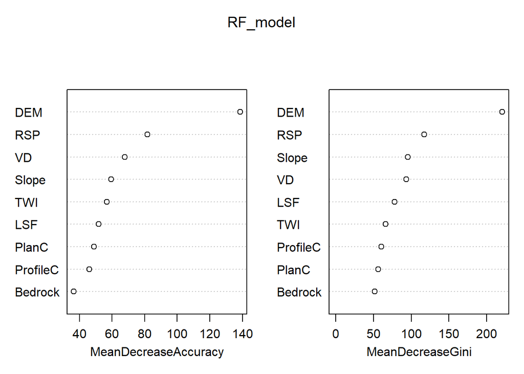

```r
sampleNum_dict[mn]<-nrow(sampData)

sampData$Bedrock<- droplevels(as.factor(sampData$Bedrock))
sampData$soilID<- droplevels(as.factor(sampData$soilID))

RF_model<-randomForest(soilID ~.,data = sampData,
                       importance = TRUE, proximity = FALSE,
                       ntree=1000,type="classification")

varImpPlot(RF_model)
```

```r
print(RF_model)
```

```
##
## Call:
##  randomForest(formula = soilID ~ ., data = sampData, importance = TRUE,      proximity = FALSE, ntree = 1000, type = "classification")
##                Type of random forest: classification
##                      Number of trees: 1000
## No. of variables tried at each split: 3
##
##         OOB estimate of  error rate: 24.22%
## Confusion matrix:
##     1 20 21 23  3 30 31 501 502 503   7 class.error
## 1   3  0  0  0  3  0  0   0   0   0   0  0.50000000
## 20  0 70  8  0  0  0  0   4   2  34  10  0.45312500
## 21  0 17 19  0  0  0  0   1   1   6   1  0.57777778
## 23  0  0  0 60  0  1  4   0   0  15   3  0.27710843
## 3   2  0  0  0 44  0  0  13   0   0   0  0.25423729
## 30  0  0  0  6  0 10  1   0   0   0   2  0.47368421
## 31  0  0  0  4  0  0 35   0   0   0   0  0.10256410
## 501 0  0  0  0  7  0  0 182   0   0   8  0.07614213
## 502 0  5  1  0  0  0  0   3  11   0   2  0.50000000
## 503 0 22  0  7  0  0  0   0   0 208  11  0.16129032
## 7   0 12  0  1  0  2  0  13   1   8 112  0.24832215
```

```r
map_RF <- predict(covStack, RF_model, paste(result_tif_folder,mn,".tif",sep=""),
                  format = "GTiff", datatype = "FLT4S", overwrite = TRUE)

rm("mn","shpPoint","sampData","RF_model","map_RF")
```

## ns7

RANst DEM ns7 15

```r
mn="All_pRANst_DEM_NS7_pen15"

shpPoint<-readOGR(paste(point_shp_folder,mn,".shp",sep = "")) ###
sampData <- extract(covStack, shpPoint, sp = TRUE,method = "simple")

sampData<-sampData@data

sampData<-sampData[sampData$soilID %in% soil_type,]

sampData<-na.omit(sampData)

print(dim(sampData))
```

```
## [1] 131  10
```

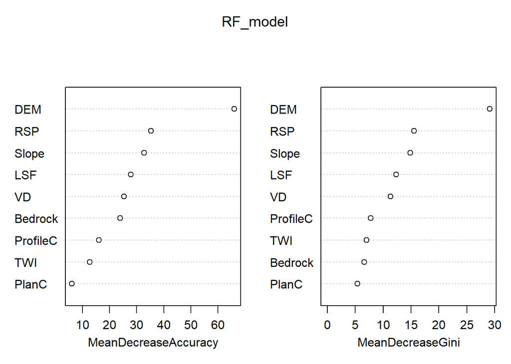

```r
sampleNum_dict[mn]<-nrow(sampData)

sampData$Bedrock<- droplevels(as.factor(sampData$Bedrock))
sampData$soilID<- droplevels(as.factor(sampData$soilID))

RF_model<-randomForest(soilID ~.,data = sampData,
                       importance = TRUE, proximity = FALSE,
                       ntree=1000,type="classification")

varImpPlot(RF_model)
```

```r
print(RF_model)
```

```
##
## Call:
##  randomForest(formula = soilID ~ ., data = sampData, importance = TRUE,      proximity = FALSE, ntree = 1000, type = "classification")
##                Type of random forest: classification
##                      Number of trees: 1000
## No. of variables tried at each split: 3
##
##         OOB estimate of  error rate: 29.77%
## Confusion matrix:
##     1 20 21 23 3 30 31 501 502 503  7 class.error
## 1   0  0  0  0 1  0  0   0   0   0  0   1.0000000
## 20  0 14  1  0 0  0  0   0   0   2  1   0.2222222
## 21  0  3  1  0 0  0  0   0   0   0  0   0.7500000
## 23  0  0  0  8 0  1  1   0   0   2  0   0.3333333
## 3   0  0  0  0 6  0  0   1   0   0  0   0.1428571
## 30  0  0  0  2 0  0  0   0   0   0  1   1.0000000
## 31  0  0  0  2 0  0  2   0   0   0  0   0.5000000
## 501 0  0  0  0 2  0  0  21   0   0  2   0.1600000
## 502 0  0  0  0 0  0  0   0   2   0  2   0.5000000
## 503 0  4  0  2 0  0  0   0   0  24  1   0.2258065
## 7   0  0  0  1 0  0  0   4   2   1 14   0.3636364
```

```r
map_RF <- predict(covStack, RF_model, paste(result_tif_folder,mn,".tif",sep=""),
                  format = "GTiff", datatype = "FLT4S", overwrite = TRUE)

rm("mn","shpPoint","sampData","RF_model","map_RF")
```

RANst DEM ns7 30

```r
mn="All_pRANst_DEM_NS7_pen30"

shpPoint<-readOGR(paste(point_shp_folder,mn,".shp",sep = "")) ###
sampData <- extract(covStack, shpPoint, sp = TRUE,method = "simple")

sampData<-sampData@data

sampData<-sampData[sampData$soilID %in% soil_type,]

sampData<-na.omit(sampData)

print(dim(sampData))
```

```
## [1] 227  10
```

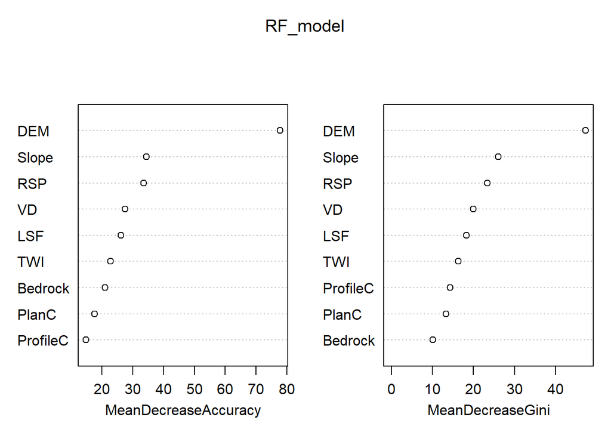

```r
sampleNum_dict[mn]<-nrow(sampData)

sampData$Bedrock<- droplevels(as.factor(sampData$Bedrock))
sampData$soilID<- droplevels(as.factor(sampData$soilID))

RF_model<-randomForest(soilID ~.,data = sampData,
                       importance = TRUE, proximity = FALSE,
                       ntree=1000,type="classification")

varImpPlot(RF_model)
```

```r
print(RF_model)
```

```
##
## Call:
##  randomForest(formula = soilID ~ ., data = sampData, importance = TRUE,      proximity = FALSE, ntree = 1000, type = "classification")
##                Type of random forest: classification
##                      Number of trees: 1000
## No. of variables tried at each split: 3
##
##         OOB estimate of  error rate: 37%
## Confusion matrix:
##     1 20 21 23 3 30 31 501 502 503  7 class.error
## 1   0  0  0  0 1  0  0   0   0   0  0   1.0000000
## 20  0 11  1  0 0  0  0   2   0   9  4   0.5925926
## 21  0  5  1  0 0  0  0   0   0   0  0   0.8333333
## 23  0  0  0 12 0  0  0   0   0   6  2   0.4000000
## 3   1  0  0  0 6  0  0   6   0   0  0   0.5384615
## 30  0  0  0  2 0  0  1   0   0   0  1   1.0000000
## 31  0  0  0  3 0  0  4   0   0   0  0   0.4285714
## 501 0  1  0  0 5  0  0  40   0   0  3   0.1836735
## 502 0  0  0  0 1  0  0   0   2   0  3   0.6666667
## 503 0  8  0  4 0  0  0   0   0  41  3   0.2678571
## 7   0  3  0  1 0  0  1   5   1   1 26   0.3157895
```

```r
map_RF <- predict(covStack, RF_model, paste(result_tif_folder,mn,".tif",sep=""),
                  format = "GTiff", datatype = "FLT4S", overwrite = TRUE)

rm("mn","shpPoint","sampData","RF_model","map_RF")
```

RANst DEM ns7 45

```r
mn="All_pRANst_DEM_NS7_pen45"

shpPoint<-readOGR(paste(point_shp_folder,mn,".shp",sep = "")) ###
sampData <- extract(covStack, shpPoint, sp = TRUE,method = "simple")

sampData<-sampData@data

sampData<-sampData[sampData$soilID %in% soil_type,]

sampData<-na.omit(sampData)

print(dim(sampData))
```

```
## [1] 327  10
```

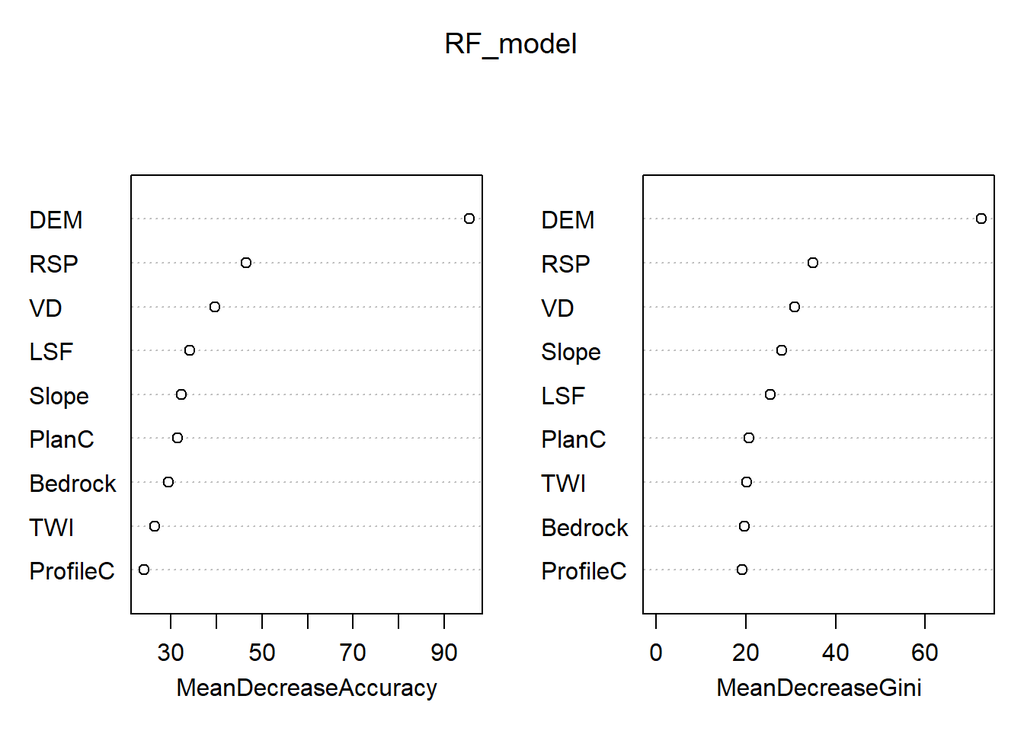

```r
sampleNum_dict[mn]<-nrow(sampData)

sampData$Bedrock<- droplevels(as.factor(sampData$Bedrock))
sampData$soilID<- droplevels(as.factor(sampData$soilID))

RF_model<-randomForest(soilID ~.,data = sampData,
                       importance = TRUE, proximity = FALSE,
                       ntree=1000,type="classification")

varImpPlot(RF_model)
```

```r
print(RF_model)
```

```
##
## Call:
##  randomForest(formula = soilID ~ ., data = sampData, importance = TRUE,      proximity = FALSE, ntree = 1000, type = "classification")
##                Type of random forest: classification
##                      Number of trees: 1000
## No. of variables tried at each split: 3
##
##         OOB estimate of  error rate: 28.13%
## Confusion matrix:
##     1 20 21 23  3 30 31 501 502 503  7 class.error
## 1   0  0  0  0  2  0  0   0   0   0  0  1.00000000
## 20  0 21  2  0  0  0  0   1   0   6  6  0.41666667
## 21  0  6  0  0  0  0  0   0   0   1  1  1.00000000
## 23  0  0  0 20  0  0  2   0   0   7  0  0.31034483
## 3   1  0  0  0 10  0  0   9   0   0  0  0.50000000
## 30  0  0  0  1  0  2  0   0   0   1  1  0.60000000
## 31  0  0  0  1  0  0  8   0   0   1  0  0.20000000
## 501 0  0  0  0  6  0  0  67   0   0  1  0.09459459
## 502 0  3  0  0  0  0  0   2   2   0  1  0.75000000
## 503 0  9  0  5  0  1  0   0   0  65  3  0.21686747
## 7   0  3  0  0  0  1  0   5   0   3 40  0.23076923
```

```r
map_RF <- predict(covStack, RF_model, paste(result_tif_folder,mn,".tif",sep=""),
                  format = "GTiff", datatype = "FLT4S", overwrite = TRUE)

rm("mn","shpPoint","sampData","RF_model","map_RF")
```

# Slope -ok

## ns3

RANst Slope ns3 15

```r
mn="All_pRANst_Slope_NS3_pen15"

shpPoint<-readOGR(paste(point_shp_folder,mn,".shp",sep = "")) ###
sampData <- extract(covStack, shpPoint, sp = TRUE,method = "simple")

sampData<-sampData@data

sampData<-sampData[sampData$soilID %in% soil_type,]

sampData<-na.omit(sampData)

print(dim(sampData))
```

```
## [1] 996  10
```

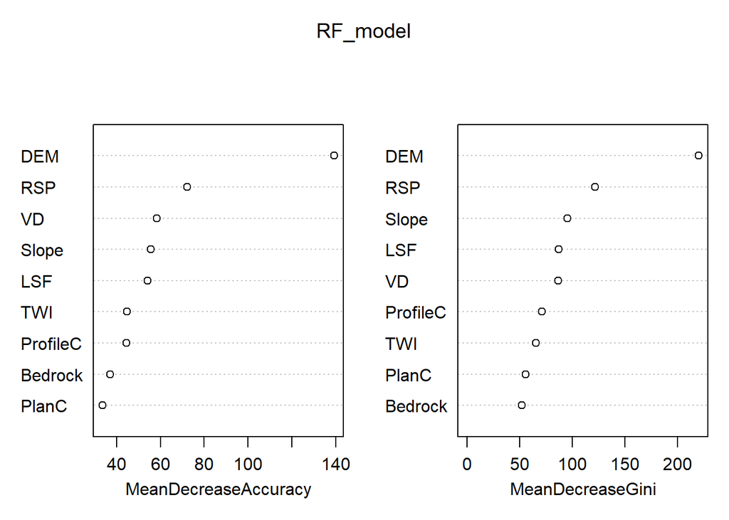

```r
sampleNum_dict[mn]<-nrow(sampData)

sampData$Bedrock<- droplevels(as.factor(sampData$Bedrock))
sampData$soilID<- droplevels(as.factor(sampData$soilID))

RF_model<-randomForest(soilID ~.,data = sampData,
                       importance = TRUE, proximity = FALSE,
                       ntree=1000,type="classification")

varImpPlot(RF_model)
```

```r
print(RF_model)
```

```
##
## Call:
##  randomForest(formula = soilID ~ ., data = sampData, importance = TRUE,      proximity = FALSE, ntree = 1000, type = "classification")
##                Type of random forest: classification
##                      Number of trees: 1000
## No. of variables tried at each split: 3
##
##         OOB estimate of  error rate: 30.12%
## Confusion matrix:
##     1 20 21 23  3 30 31 501 502 503   7 class.error
## 1   5  0  0  0  1  0  0   0   0   0   0   0.1666667
## 20  0 82 15  0  0  1  0   4   1  35  17   0.4709677
## 21  0 22 33  0  0  0  0   0   1   3   0   0.4406780
## 23  0  0  0 63  0  6  6   0   0  21   4   0.3700000
## 3   2  0  0  0 37  0  0  13   0   0   0   0.2884615
## 30  0  0  0  8  0 17  4   0   0   2   2   0.4848485
## 31  0  0  0  8  0  2 29   0   0   2   0   0.2926829
## 501 0  2  0  0 10  0  0 138   0   0   9   0.1320755
## 502 0  6  0  0  0  0  0   3  11   0   2   0.5000000
## 503 0 29  0 15  0  1  0   0   0 177   6   0.2236842
## 7   0 13  0  3  0  2  0  11   0   8 104   0.2624113
```

```r
map_RF <- predict(covStack, RF_model, paste(result_tif_folder,mn,".tif",sep=""),
                  format = "GTiff", datatype = "FLT4S", overwrite = TRUE)

rm("mn","shpPoint","sampData","RF_model","map_RF")
```

RANst Slope ns3 30

```r
mn="All_pRANst_Slope_NS3_pen30"

shpPoint<-readOGR(paste(point_shp_folder,mn,".shp",sep = "")) ###
sampData <- extract(covStack, shpPoint, sp = TRUE,method = "simple")

sampData<-sampData@data

sampData<-sampData[sampData$soilID %in% soil_type,]

sampData<-na.omit(sampData)

print(dim(sampData))
```

```
## [1] 1948   10
```

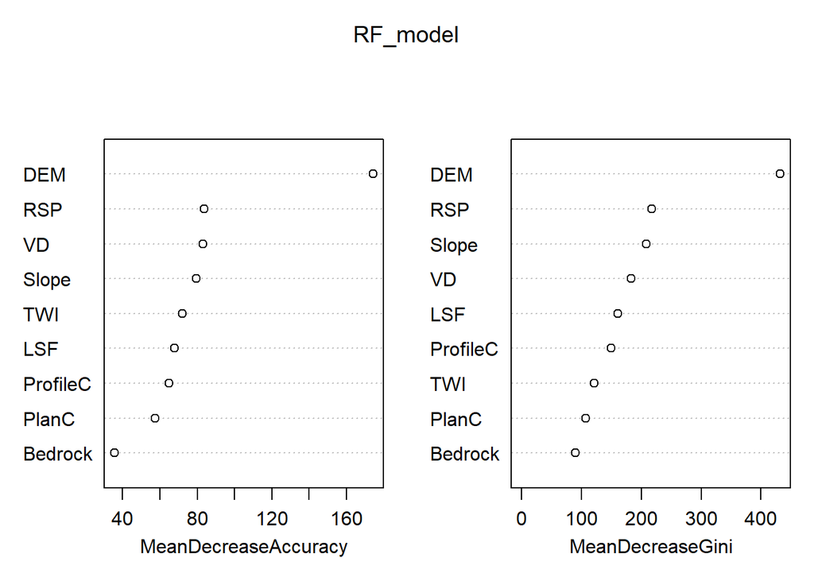

```r
sampleNum_dict[mn]<-nrow(sampData)

sampData$Bedrock<- droplevels(as.factor(sampData$Bedrock))
sampData$soilID<- droplevels(as.factor(sampData$soilID))

RF_model<-randomForest(soilID ~.,data = sampData,
                       importance = TRUE, proximity = FALSE,
                       ntree=1000,type="classification")

varImpPlot(RF_model)
```

```r
print(RF_model)
```

```
##
## Call:
##  randomForest(formula = soilID ~ ., data = sampData, importance = TRUE,      proximity = FALSE, ntree = 1000, type = "classification")
##                Type of random forest: classification
##                      Number of trees: 1000
## No. of variables tried at each split: 3
##
##         OOB estimate of  error rate: 26.18%
## Confusion matrix:
##     1  20 21  23  3 30 31 501 502 503   7 class.error
## 1   9   0  0   0  2  0  0   0   0   0   0   0.1818182
## 20  0 185 30   1  0  0  0   7   2  51  27   0.3894389
## 21  0  47 52   0  0  0  0   0   3   7   2   0.5315315
## 23  0   0  0 131  0 10  6   0   0  35   9   0.3141361
## 3   3   0  0   0 76  0  0  25   0   0   0   0.2692308
## 30  0   0  0  16  0 34  7   0   0   1   5   0.4603175
## 31  0   0  0  16  0  4 60   0   0   2   0   0.2682927
## 501 0   1  0   0 15  0  0 285   0   0  16   0.1009464
## 502 0   5  2   0  0  0  0   2  28   0   4   0.3170732
## 503 0  52  2  17  0  2  1   0   0 369   6   0.1781737
## 7   0  25  0   2  0  5  0  17   0  18 209   0.2427536
```

```r
map_RF <- predict(covStack, RF_model, paste(result_tif_folder,mn,".tif",sep=""),
                  format = "GTiff", datatype = "FLT4S", overwrite = TRUE)

rm("mn","shpPoint","sampData","RF_model","map_RF")
```

RANst Slope ns3 45

```r
mn="All_pRANst_Slope_NS3_pen45"

shpPoint<-readOGR(paste(point_shp_folder,mn,".shp",sep = "")) ###
sampData <- extract(covStack, shpPoint, sp = TRUE,method = "simple")

sampData<-sampData@data

sampData<-sampData[sampData$soilID %in% soil_type,]

sampData<-na.omit(sampData)

print(dim(sampData))
```

```
## [1] 2886   10
```

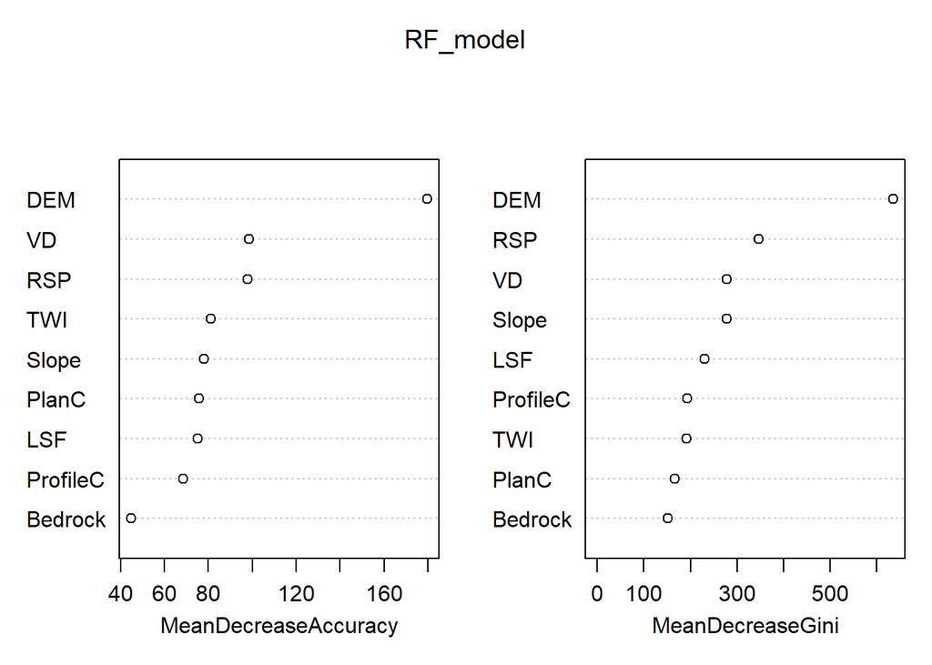

```r
sampleNum_dict[mn]<-nrow(sampData)

sampData$Bedrock<- droplevels(as.factor(sampData$Bedrock))
sampData$soilID<- droplevels(as.factor(sampData$soilID))

RF_model<-randomForest(soilID ~.,data = sampData,
                       importance = TRUE, proximity = FALSE,
                       ntree=1000,type="classification")

varImpPlot(RF_model)
```

```r
print(RF_model)
```

```
##
## Call:
##  randomForest(formula = soilID ~ ., data = sampData, importance = TRUE,      proximity = FALSE, ntree = 1000, type = "classification")
##                Type of random forest: classification
##                      Number of trees: 1000
## No. of variables tried at each split: 3
##
##         OOB estimate of  error rate: 24.88%
## Confusion matrix:
##      1  20 21  23   3 30  31 501 502 503   7 class.error
## 1   15   0  0   0   2  0   0   0   0   0   0   0.1176471
## 20   0 302 27   2   0  1   0   7   2  77  29   0.3243848
## 21   0  63 82   0   0  0   0   1   2  10   3   0.4906832
## 23   0   0  0 200   0 10   7   0   0  53  12   0.2907801
## 3    4   0  0   0 106  0   0  45   0   0   0   0.3161290
## 30   0   0  0  21   0 52   8   0   0   3   7   0.4285714
## 31   0   0  0  17   0  6 100   0   0   0   0   0.1869919
## 501  0   4  0   0  27  0   0 419   0   0  24   0.1160338
## 502  0   5  1   0   0  0   0   1  42   0  11   0.3000000
## 503  0  59  7  39   0  4   1   0   1 538  19   0.1946108
## 7    0  23  2   2   0  6   0  30   4  29 312   0.2352941
```

```r
map_RF <- predict(covStack, RF_model, paste(result_tif_folder,mn,".tif",sep=""),
                  format = "GTiff", datatype = "FLT4S", overwrite = TRUE)

rm("mn","shpPoint","sampData","RF_model","map_RF")
```

## ns5

RANst Slope ns5 15

```r
mn="All_pRANst_Slope_NS5_pen15"

shpPoint<-readOGR(paste(point_shp_folder,mn,".shp",sep = "")) ###
sampData <- extract(covStack, shpPoint, sp = TRUE,method = "simple")

sampData<-sampData@data

sampData<-sampData[sampData$soilID %in% soil_type,]

sampData<-na.omit(sampData)

print(dim(sampData))
```

```
## [1] 336  10
```

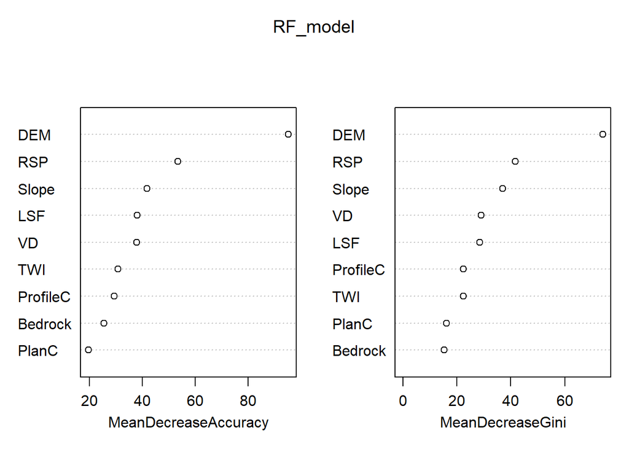

```r
sampleNum_dict[mn]<-nrow(sampData)

sampData$Bedrock<- droplevels(as.factor(sampData$Bedrock))
sampData$soilID<- droplevels(as.factor(sampData$soilID))

RF_model<-randomForest(soilID ~.,data = sampData,
                       importance = TRUE, proximity = FALSE,
                       ntree=1000,type="classification")

varImpPlot(RF_model)
```

```r
print(RF_model)
```

```
##
## Call:
##  randomForest(formula = soilID ~ ., data = sampData, importance = TRUE,      proximity = FALSE, ntree = 1000, type = "classification")
##                Type of random forest: classification
##                      Number of trees: 1000
## No. of variables tried at each split: 3
##
##         OOB estimate of  error rate: 30.95%
## Confusion matrix:
##     1 20 21 23  3 30 31 501 502 503  7 class.error
## 1   0  0  0  0  2  0  0   0   0   0  0  1.00000000
## 20  0 24  8  0  0  0  0   0   0  10  4  0.47826087
## 21  0 10  9  0  0  0  0   0   0   1  1  0.57142857
## 23  0  0  0 15  0  3  3   0   0   7  1  0.48275862
## 3   2  0  0  0 11  0  0   6   0   0  0  0.42105263
## 30  0  0  0  5  0  2  1   0   0   0  1  0.77777778
## 31  0  0  0  2  0  1 10   0   0   0  0  0.23076923
## 501 0  1  0  0  3  0  0  55   0   0  2  0.09836066
## 502 0  3  0  0  0  0  0   1   2   0  1  0.71428571
## 503 0  6  2  2  0  0  0   0   0  66  2  0.15384615
## 7   0  4  0  0  0  2  1   3   0   3 38  0.25490196
```

```r
map_RF <- predict(covStack, RF_model, paste(result_tif_folder,mn,".tif",sep=""),
                  format = "GTiff", datatype = "FLT4S", overwrite = TRUE)

rm("mn","shpPoint","sampData","RF_model","map_RF")
```

RANst Slope ns5 30

```r
mn="All_pRANst_Slope_NS5_pen30"

shpPoint<-readOGR(paste(point_shp_folder,mn,".shp",sep = "")) ###
sampData <- extract(covStack, shpPoint, sp = TRUE,method = "simple")

sampData<-sampData@data

sampData<-sampData[sampData$soilID %in% soil_type,]

sampData<-na.omit(sampData)

print(dim(sampData))
```

```
## [1] 636  10
```

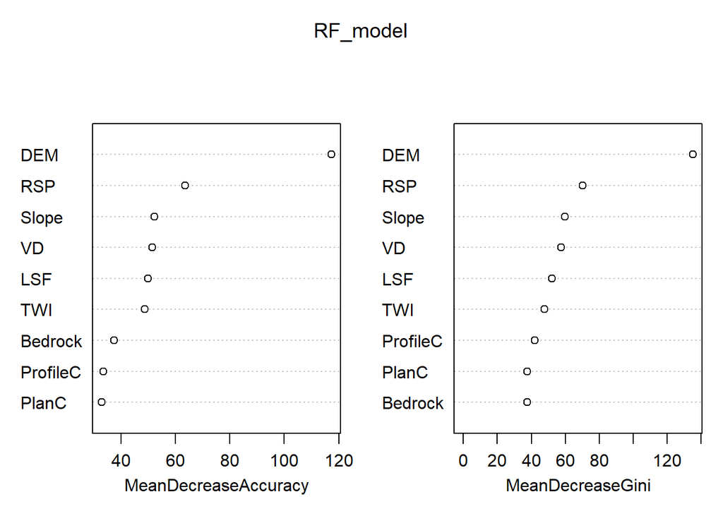

```r
sampleNum_dict[mn]<-nrow(sampData)

sampData$Bedrock<- droplevels(as.factor(sampData$Bedrock))
sampData$soilID<- droplevels(as.factor(sampData$soilID))

RF_model<-randomForest(soilID ~.,data = sampData,
                       importance = TRUE, proximity = FALSE,
                       ntree=1000,type="classification")

varImpPlot(RF_model)
```

```r
print(RF_model)
```

```
##
## Call:
##  randomForest(formula = soilID ~ ., data = sampData, importance = TRUE,      proximity = FALSE, ntree = 1000, type = "classification")
##                Type of random forest: classification
##                      Number of trees: 1000
## No. of variables tried at each split: 3
##
##         OOB estimate of  error rate: 29.72%
## Confusion matrix:
##     1 20 21 23  3 30 31 501 502 503  7 class.error
## 1   4  0  0  0  0  0  0   0   0   0  0   0.0000000
## 20  0 54  5  0  0  0  0   3   0  17  7   0.3720930
## 21  0 14 13  0  0  0  0   0   1   2  3   0.6060606
## 23  0  0  0 30  0  6  3   0   0  14  1   0.4444444
## 3   1  0  0  0 22  0  0  14   0   0  0   0.4054054
## 30  0  0  0  4  0  7  1   0   0   2  2   0.5625000
## 31  0  0  0  4  0  0 19   0   0   2  0   0.2400000
## 501 0  1  0  0  7  0  0 107   0   0  6   0.1157025
## 502 0  1  0  0  0  0  0   4   6   0  3   0.5714286
## 503 0 16  4  8  0  2  1   0   0 115  5   0.2384106
## 7   0  7  0  1  0  2  0   7   1   7 70   0.2631579
```

```r
map_RF <- predict(covStack, RF_model, paste(result_tif_folder,mn,".tif",sep=""),
                  format = "GTiff", datatype = "FLT4S", overwrite = TRUE)

rm("mn","shpPoint","sampData","RF_model","map_RF")
```

RANst Slope ns5 45

```r
mn="All_pRANst_Slope_NS5_pen45"

shpPoint<-readOGR(paste(point_shp_folder,mn,".shp",sep = "")) ###
sampData <- extract(covStack, shpPoint, sp = TRUE,method = "simple")

sampData<-sampData@data

sampData<-sampData[sampData$soilID %in% soil_type,]

sampData<-na.omit(sampData)

print(dim(sampData))
```

```
## [1] 931  10
```

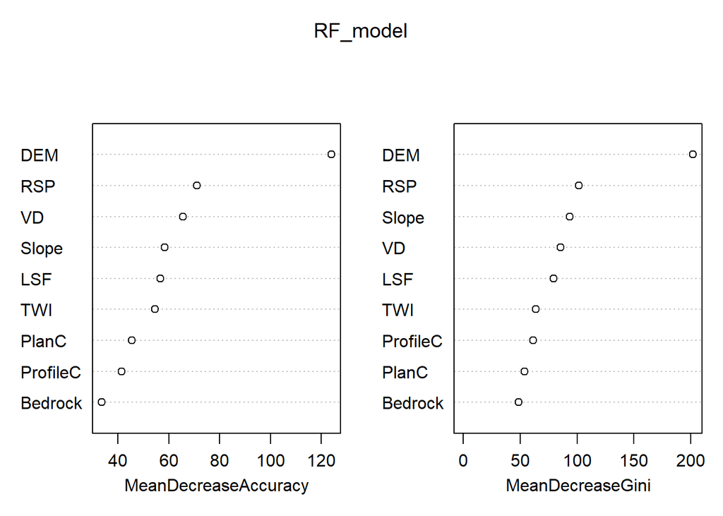

```r
sampleNum_dict[mn]<-nrow(sampData)

sampData$Bedrock<- droplevels(as.factor(sampData$Bedrock))
sampData$soilID<- droplevels(as.factor(sampData$soilID))

RF_model<-randomForest(soilID ~.,data = sampData,
                       importance = TRUE, proximity = FALSE,
                       ntree=1000,type="classification")

varImpPlot(RF_model)
```

```r
print(RF_model)
```

```
##
## Call:
##  randomForest(formula = soilID ~ ., data = sampData, importance = TRUE,      proximity = FALSE, ntree = 1000, type = "classification")
##                Type of random forest: classification
##                      Number of trees: 1000
## No. of variables tried at each split: 3
##
##         OOB estimate of  error rate: 29.43%
## Confusion matrix:
##     1 20 21 23  3 30 31 501 502 503   7 class.error
## 1   3  0  0  0  3  0  0   0   0   0   0   0.5000000
## 20  0 58 12  0  0  0  0   1   0  31  18   0.5166667
## 21  0 20 22  0  0  0  0   0   2   3   0   0.5319149
## 23  0  1  0 45  0  4  3   0   0  17  10   0.4375000
## 3   3  0  0  0 40  0  0  12   0   0   0   0.2727273
## 30  0  0  0  6  0  9  5   0   0   2   0   0.5909091
## 31  0  0  0  6  0  1 30   0   0   0   0   0.1891892
## 501 0  1  0  0 10  0  0 160   1   0   9   0.1160221
## 502 0  3  1  0  0  0  0   6   7   2   1   0.6500000
## 503 0 16  4 13  0  0  0   0   0 179  11   0.1973094
## 7   0 11  0  1  0  0  0  13   1  10 104   0.2571429
```

```r
map_RF <- predict(covStack, RF_model, paste(result_tif_folder,mn,".tif",sep=""),
                  format = "GTiff", datatype = "FLT4S", overwrite = TRUE)

rm("mn","shpPoint","sampData","RF_model","map_RF")
```

## ns7

RANst Slope ns7 15

```r
mn="All_pRANst_Slope_NS7_pen15"

shpPoint<-readOGR(paste(point_shp_folder,mn,".shp",sep = "")) ###
sampData <- extract(covStack, shpPoint, sp = TRUE,method = "simple")

sampData<-sampData@data

sampData<-sampData[sampData$soilID %in% soil_type,]

sampData<-na.omit(sampData)

print(dim(sampData))
```

```
## [1] 121  10
```

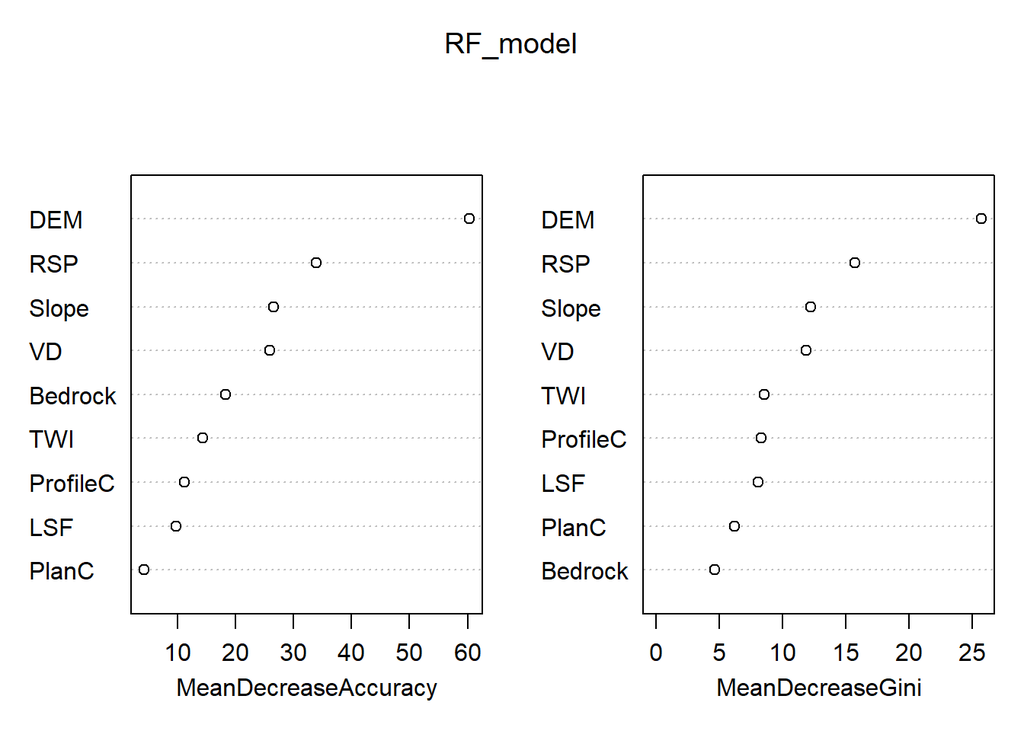

```r
sampleNum_dict[mn]<-nrow(sampData)

sampData$Bedrock<- droplevels(as.factor(sampData$Bedrock))
sampData$soilID<- droplevels(as.factor(sampData$soilID))

RF_model<-randomForest(soilID ~.,data = sampData,
                       importance = TRUE, proximity = FALSE,
                       ntree=1000,type="classification")

varImpPlot(RF_model)
```

```r
print(RF_model)
```

```
##
## Call:
##  randomForest(formula = soilID ~ ., data = sampData, importance = TRUE,      proximity = FALSE, ntree = 1000, type = "classification")
##                Type of random forest: classification
##                      Number of trees: 1000
## No. of variables tried at each split: 3
##
##         OOB estimate of  error rate: 41.32%
## Confusion matrix:
##     1 20 21 23 3 30 31 501 502 503  7 class.error
## 1   0  0  0  0 1  0  0   0   0   0  0   1.0000000
## 20  0  7  3  0 0  0  0   0   0   3  5   0.6111111
## 21  0  3  1  0 0  0  0   0   0   0  0   0.7500000
## 23  0  0  0  8 0  0  0   0   0   2  0   0.2000000
## 3   0  0  0  0 4  0  0   3   0   0  0   0.4285714
## 30  0  0  0  2 0  0  0   0   0   0  0   1.0000000
## 31  0  0  0  3 0  0  1   0   0   0  0   0.7500000
## 501 0  1  0  0 3  0  0  18   0   0  1   0.2173913
## 502 0  0  0  0 1  0  0   2   0   0  0   1.0000000
## 503 0  6  0  0 0  0  0   0   0  22  1   0.2413793
## 7   0  2  0  1 0  0  0   2   0   5 10   0.5000000
```

```r
map_RF <- predict(covStack, RF_model, paste(result_tif_folder,mn,".tif",sep=""),
                  format = "GTiff", datatype = "FLT4S", overwrite = TRUE)

rm("mn","shpPoint","sampData","RF_model","map_RF")
```

RANst Slope ns7 30

```r
mn="All_pRANst_Slope_NS7_pen30"

shpPoint<-readOGR(paste(point_shp_folder,mn,".shp",sep = "")) ###
sampData <- extract(covStack, shpPoint, sp = TRUE,method = "simple")

sampData<-sampData@data

sampData<-sampData[sampData$soilID %in% soil_type,]

sampData<-na.omit(sampData)

print(dim(sampData))
```

```
## [1] 214  10
```

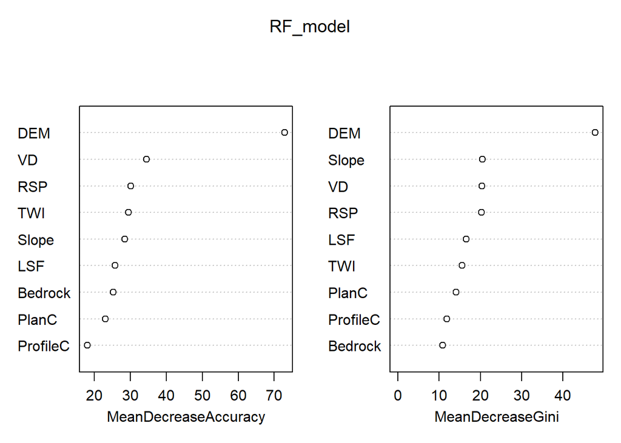

```r
sampleNum_dict[mn]<-nrow(sampData)

sampData$Bedrock<- droplevels(as.factor(sampData$Bedrock))
sampData$soilID<- droplevels(as.factor(sampData$soilID))

RF_model<-randomForest(soilID ~.,data = sampData,
                       importance = TRUE, proximity = FALSE,
                       ntree=1000,type="classification")

varImpPlot(RF_model)
```

```r
print(RF_model)
```

```
##
## Call:
##  randomForest(formula = soilID ~ ., data = sampData, importance = TRUE,      proximity = FALSE, ntree = 1000, type = "classification")
##                Type of random forest: classification
##                      Number of trees: 1000
## No. of variables tried at each split: 3
##
##         OOB estimate of  error rate: 30.84%
## Confusion matrix:
##     1 20 21 23 3 30 31 501 502 503  7 class.error
## 1   0  0  0  0 1  0  0   0   0   0  0   1.0000000
## 20  0 17  0  0 0  0  0   0   1   4  5   0.3703704
## 21  0  3  1  0 0  0  0   0   0   1  0   0.8000000
## 23  0  0  0  6 0  0  4   0   0   6  1   0.6470588
## 3   0  0  0  0 6  0  0   8   0   0  0   0.5714286
## 30  0  0  0  2 0  0  0   0   0   0  1   1.0000000
## 31  0  0  0  2 0  0  5   0   0   0  0   0.2857143
## 501 0  0  0  0 3  0  0  39   0   0  4   0.1521739
## 502 0  0  1  0 0  0  0   2   1   1  0   0.8000000
## 503 0  3  0  2 0  0  0   0   0  46  2   0.1320755
## 7   0  3  0  3 0  0  0   3   0   0 27   0.2500000
```

```r
map_RF <- predict(covStack, RF_model, paste(result_tif_folder,mn,".tif",sep=""),
                  format = "GTiff", datatype = "FLT4S", overwrite = TRUE)

rm("mn","shpPoint","sampData","RF_model","map_RF")
```

RANst Slope ns7 45

```r
mn="All_pRANst_Slope_NS7_pen45"

shpPoint<-readOGR(paste(point_shp_folder,mn,".shp",sep = "")) ###
sampData <- extract(covStack, shpPoint, sp = TRUE,method = "simple")

sampData<-sampData@data

sampData<-sampData[sampData$soilID %in% soil_type,]

sampData<-na.omit(sampData)

print(dim(sampData))
```

```
## [1] 307  10
```

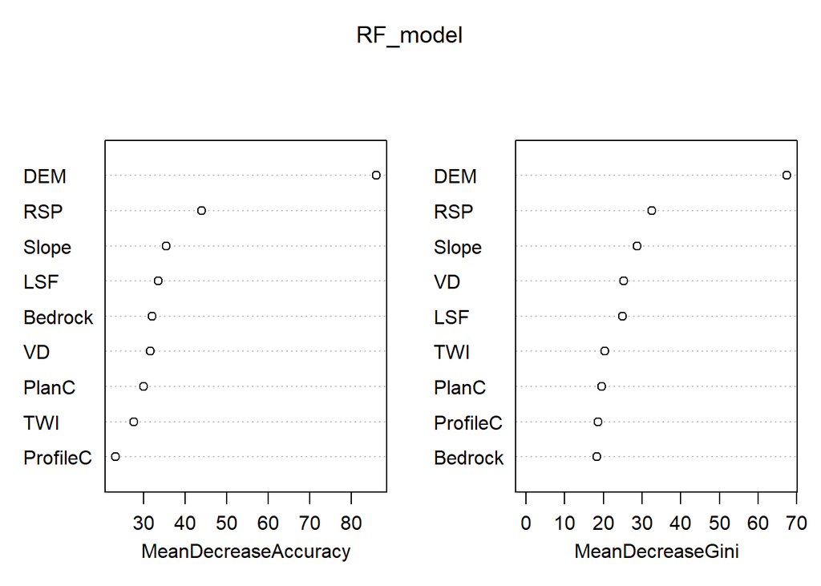

```r
sampleNum_dict[mn]<-nrow(sampData)

sampData$Bedrock<- droplevels(as.factor(sampData$Bedrock))
sampData$soilID<- droplevels(as.factor(sampData$soilID))

RF_model<-randomForest(soilID ~.,data = sampData,
                       importance = TRUE, proximity = FALSE,
                       ntree=1000,type="classification")

varImpPlot(RF_model)
```

```r
print(RF_model)
```

```
##
## Call:
##  randomForest(formula = soilID ~ ., data = sampData, importance = TRUE,      proximity = FALSE, ntree = 1000, type = "classification")
##                Type of random forest: classification
##                      Number of trees: 1000
## No. of variables tried at each split: 3
##
##         OOB estimate of  error rate: 31.92%
## Confusion matrix:
##     1 20 21 23 3 30 31 501 502 503  7 class.error
## 1   1  0  0  0 1  0  0   0   0   0  0   0.5000000
## 20  0 18  2  0 0  0  1   0   0   7  8   0.5000000
## 21  0  4  3  0 0  0  0   0   0   0  1   0.6250000
## 23  0  0  0 12 0  1  3   0   0   9  1   0.5384615
## 3   0  0  0  0 5  0  0  15   0   0  0   0.7500000
## 30  0  0  0  3 0  0  0   0   0   1  0   1.0000000
## 31  0  0  0  2 0  0  7   0   0   1  0   0.3000000
## 501 0  0  0  0 5  0  0  62   0   0  2   0.1014493
## 502 0  0  0  0 0  0  0   3   2   0  2   0.7142857
## 503 0  6  0  4 0  0  0   0   0  63  3   0.1710526
## 7   0  4  0  0 0  0  0   5   0   4 36   0.2653061
```

```r
map_RF <- predict(covStack, RF_model, paste(result_tif_folder,mn,".tif",sep=""),
                  format = "GTiff", datatype = "FLT4S", overwrite = TRUE)

rm("mn","shpPoint","sampData","RF_model","map_RF")
```

# PlanC -ok

## ns3

RANst PlanC ns3 15

```r
mn="All_pRANst_PlanC_NS3_pen15"

shpPoint<-readOGR(paste(point_shp_folder,mn,".shp",sep = "")) ###
sampData <- extract(covStack, shpPoint, sp = TRUE,method = "simple")

sampData<-sampData@data

sampData<-sampData[sampData$soilID %in% soil_type,]

sampData<-na.omit(sampData)

print(dim(sampData))
```

```
## [1] 1011   10
```

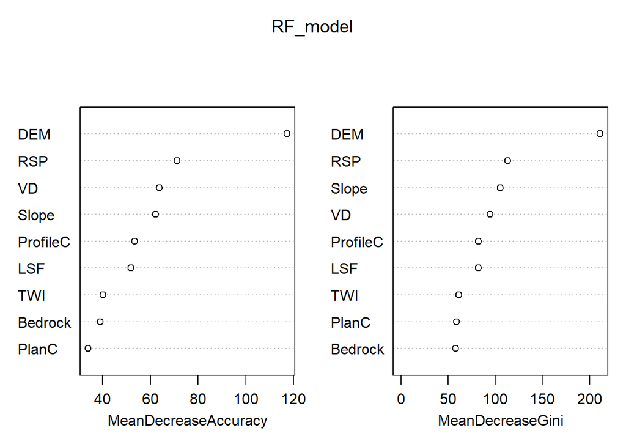

```r
sampleNum_dict[mn]<-nrow(sampData)

sampData$Bedrock<- droplevels(as.factor(sampData$Bedrock))
sampData$soilID<- droplevels(as.factor(sampData$soilID))

RF_model<-randomForest(soilID ~.,data = sampData,
                       importance = TRUE, proximity = FALSE,
                       ntree=1000,type="classification")

varImpPlot(RF_model)
```

```r
print(RF_model)
```

```
##
## Call:
##  randomForest(formula = soilID ~ ., data = sampData, importance = TRUE,      proximity = FALSE, ntree = 1000, type = "classification")
##                Type of random forest: classification
##                      Number of trees: 1000
## No. of variables tried at each split: 3
##
##         OOB estimate of  error rate: 29.87%
## Confusion matrix:
##     1 20 21 23  3 30 31 501 502 503   7 class.error
## 1   4  0  0  0  2  0  0   0   0   0   0   0.3333333
## 20  0 89 13  1  0  0  0   2   0  31  20   0.4294872
## 21  0 20 33  0  0  0  0   1   1   2   2   0.4406780
## 23  0  0  0 64  0  7  8   0   0  13   8   0.3600000
## 3   1  0  0  0 33  0  0  17   0   0   0   0.3529412
## 30  0  0  0  9  0 17  5   0   0   0   2   0.4848485
## 31  0  0  0  8  0  6 28   0   0   0   0   0.3333333
## 501 0  0  0  0 17  0  0 138   0   0  10   0.1636364
## 502 0  1  0  0  0  0  0   4  12   0   4   0.4285714
## 503 0 23  0 21  0  0  0   0   0 182   7   0.2188841
## 7   0 13  0  2  0  4  0  10   0   7 109   0.2482759
```

```r
map_RF <- predict(covStack, RF_model, paste(result_tif_folder,mn,".tif",sep=""),
                  format = "GTiff", datatype = "FLT4S", overwrite = TRUE)

rm("mn","shpPoint","sampData","RF_model","map_RF")
```

RANst PlanC ns3 30

```r
mn="All_pRANst_PlanC_NS3_pen30"

shpPoint<-readOGR(paste(point_shp_folder,mn,".shp",sep = "")) ###
sampData <- extract(covStack, shpPoint, sp = TRUE,method = "simple")

sampData<-sampData@data

sampData<-sampData[sampData$soilID %in% soil_type,]

sampData<-na.omit(sampData)

print(dim(sampData))
```

```
## [1] 1973   10
```

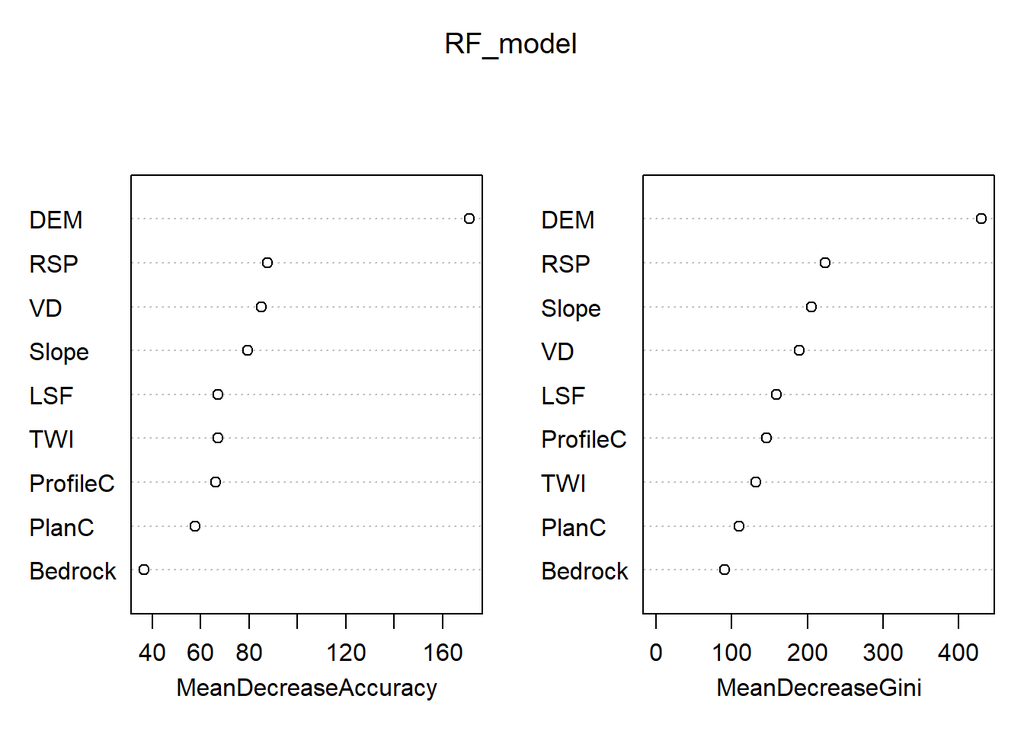

```r
sampleNum_dict[mn]<-nrow(sampData)

sampData$Bedrock<- droplevels(as.factor(sampData$Bedrock))
sampData$soilID<- droplevels(as.factor(sampData$soilID))

RF_model<-randomForest(soilID ~.,data = sampData,
                       importance = TRUE, proximity = FALSE,
                       ntree=1000,type="classification")

varImpPlot(RF_model)
```

```r
print(RF_model)
```

```
##
## Call:
##  randomForest(formula = soilID ~ ., data = sampData, importance = TRUE,      proximity = FALSE, ntree = 1000, type = "classification")
##                Type of random forest: classification
##                      Number of trees: 1000
## No. of variables tried at each split: 3
##
##         OOB estimate of  error rate: 26.71%
## Confusion matrix:
##     1  20 21  23  3 30 31 501 502 503   7 class.error
## 1   8   0  0   0  2  0  0   0   0   0   0   0.2000000
## 20  0 201 27   1  0  0  0   5   3  45  21   0.3366337
## 21  0  54 41   0  0  0  0   3   3  10   1   0.6339286
## 23  0   0  0 126  0 11  7   0   0  32  13   0.3333333
## 3   2   0  0   0 68  0  0  31   0   0   0   0.3267327
## 30  0   0  0  11  0 41  5   0   0   4   2   0.3492063
## 31  0   0  0  10  0  3 70   0   0   1   0   0.1666667
## 501 0   4  1   0 20  0  0 291   0   0  14   0.1181818
## 502 0   4  4   0  0  0  0   5  25   0   2   0.3750000
## 503 0  44  6  28  0  1  0   0   0 369  12   0.1978261
## 7   0  29  0   3  0  5  0  22   2  14 206   0.2669039
```

```r
map_RF <- predict(covStack, RF_model, paste(result_tif_folder,mn,".tif",sep=""),
                  format = "GTiff", datatype = "FLT4S", overwrite = TRUE)

rm("mn","shpPoint","sampData","RF_model","map_RF")
```

RANst PlanC ns3 45

```r
mn="All_pRANst_PlanC_NS3_pen45"

shpPoint<-readOGR(paste(point_shp_folder,mn,".shp",sep = "")) ###
sampData <- extract(covStack, shpPoint, sp = TRUE,method = "simple")

sampData<-sampData@data

sampData<-sampData[sampData$soilID %in% soil_type,]

sampData<-na.omit(sampData)

print(dim(sampData))
```

```
## [1] 2938   10
```

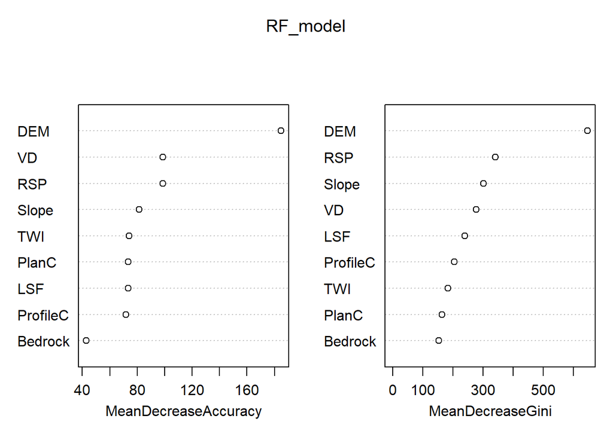

```r
sampleNum_dict[mn]<-nrow(sampData)

sampData$Bedrock<- droplevels(as.factor(sampData$Bedrock))
sampData$soilID<- droplevels(as.factor(sampData$soilID))

RF_model<-randomForest(soilID ~.,data = sampData,
                       importance = TRUE, proximity = FALSE,
                       ntree=1000,type="classification")

varImpPlot(RF_model)
```

```r
print(RF_model)
```

```
##
## Call:
##  randomForest(formula = soilID ~ ., data = sampData, importance = TRUE,      proximity = FALSE, ntree = 1000, type = "classification")
##                Type of random forest: classification
##                      Number of trees: 1000
## No. of variables tried at each split: 3
##
##         OOB estimate of  error rate: 25.09%
## Confusion matrix:
##      1  20 21  23   3 30 31 501 502 503   7 class.error
## 1   15   0  0   0   1  0  0   0   0   0   0   0.0625000
## 20   0 293 25   2   0  0  0   5   0  71  54   0.3488889
## 21   0  78 73   0   0  0  0   1   4   8   1   0.5575758
## 23   0   1  0 191   0 17 13   0   0  51   8   0.3202847
## 3    3   0  0   0 108  0  0  41   0   0   0   0.2894737
## 30   0   0  0  19   0 50  9   0   0   1  12   0.4505495
## 31   0   0  0  18   0  7 99   0   0   1   0   0.2080000
## 501  0   0  1   0  21  0  0 451   3   0  17   0.0851927
## 502  0   4  4   0   0  0  0   3  41   1   5   0.2931034
## 503  0  63  2  36   0  1  0   0   0 565  21   0.1787791
## 7    0  35  0   4   0  7  0  27   5  26 315   0.2482100
```

```r
map_RF <- predict(covStack, RF_model, paste(result_tif_folder,mn,".tif",sep=""),
                  format = "GTiff", datatype = "FLT4S", overwrite = TRUE)

rm("mn","shpPoint","sampData","RF_model","map_RF")
```

## ns5

RANst PlanC ns5 15

```r
mn="All_pRANst_PlanC_NS5_pen15"

shpPoint<-readOGR(paste(point_shp_folder,mn,".shp",sep = "")) ###
sampData <- extract(covStack, shpPoint, sp = TRUE,method = "simple")

sampData<-sampData@data

sampData<-sampData[sampData$soilID %in% soil_type,]

sampData<-na.omit(sampData)

print(dim(sampData))
```

```
## [1] 345  10
```

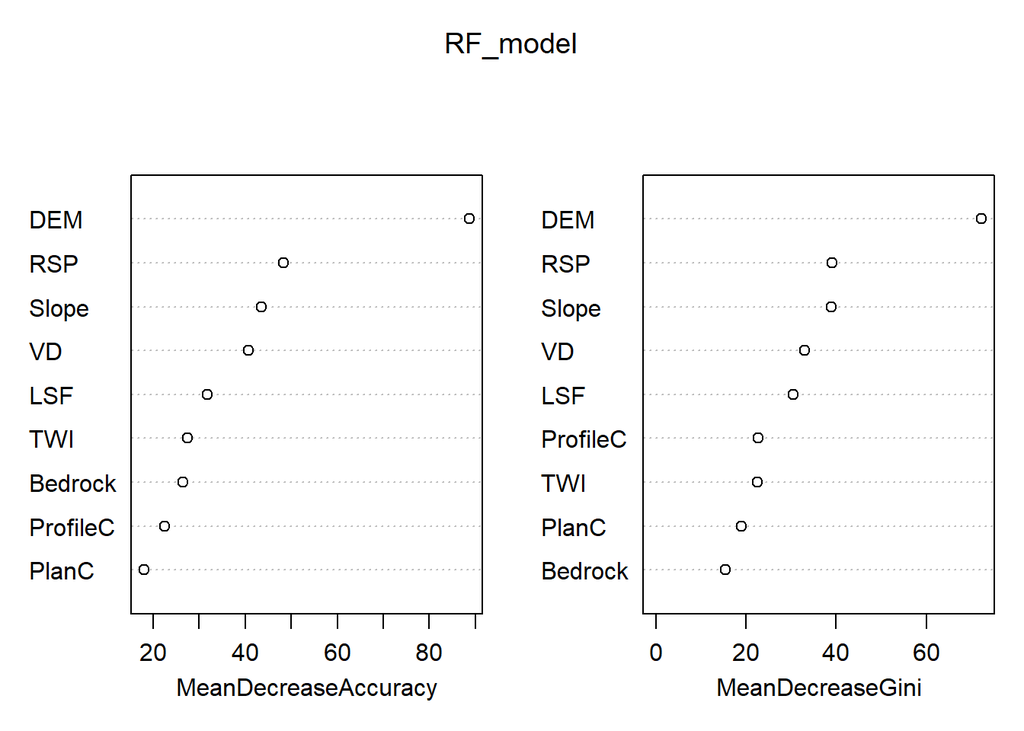

```r
sampleNum_dict[mn]<-nrow(sampData)

sampData$Bedrock<- droplevels(as.factor(sampData$Bedrock))
sampData$soilID<- droplevels(as.factor(sampData$soilID))

RF_model<-randomForest(soilID ~.,data = sampData,
                       importance = TRUE, proximity = FALSE,
                       ntree=1000,type="classification")

varImpPlot(RF_model)
```

```r
print(RF_model)
```

```
##
## Call:
##  randomForest(formula = soilID ~ ., data = sampData, importance = TRUE,      proximity = FALSE, ntree = 1000, type = "classification")
##                Type of random forest: classification
##                      Number of trees: 1000
## No. of variables tried at each split: 3
##
##         OOB estimate of  error rate: 34.2%
## Confusion matrix:
##     1 20 21 23  3 30 31 501 502 503  7 class.error
## 1   0  0  0  0  2  0  0   0   0   0  0   1.0000000
## 20  0 22  7  0  0  0  0   0   1   9  6   0.5111111
## 21  0 14  5  0  0  0  0   0   2   1  0   0.7727273
## 23  0  0  0 14  0  3  2   0   0   7  3   0.5172414
## 3   1  0  0  0 13  0  0   4   0   0  0   0.2777778
## 30  0  0  0  4  0  3  2   0   0   0  0   0.6666667
## 31  0  0  0  3  0  1  9   0   0   1  0   0.3571429
## 501 0  0  0  0  4  0  0  55   0   0  5   0.1406250
## 502 0  2  2  0  0  0  0   2   0   0  1   1.0000000
## 503 0  5  1  2  0  0  0   0   0  70  4   0.1463415
## 7   0  5  0  0  0  1  0   7   0   4 36   0.3207547
```

```r
map_RF <- predict(covStack, RF_model, paste(result_tif_folder,mn,".tif",sep=""),
                  format = "GTiff", datatype = "FLT4S", overwrite = TRUE)

rm("mn","shpPoint","sampData","RF_model","map_RF")
```

RANst PlanC ns5 30

```r
mn="All_pRANst_PlanC_NS5_pen30"

shpPoint<-readOGR(paste(point_shp_folder,mn,".shp",sep = "")) ###
sampData <- extract(covStack, shpPoint, sp = TRUE,method = "simple")

sampData<-sampData@data

sampData<-sampData[sampData$soilID %in% soil_type,]

sampData<-na.omit(sampData)

print(dim(sampData))
```

```
## [1] 650  10
```

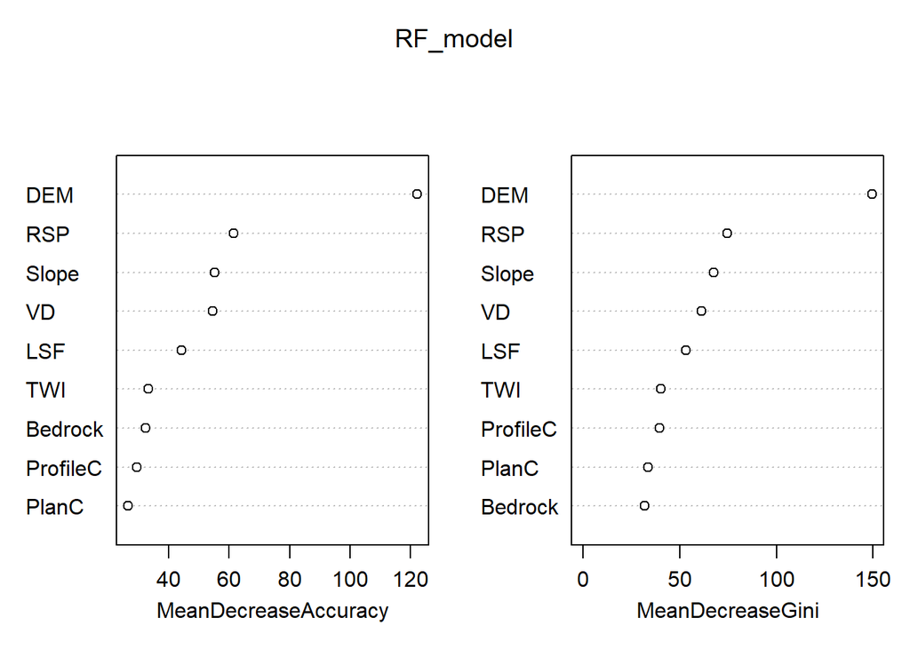

```r
sampleNum_dict[mn]<-nrow(sampData)

sampData$Bedrock<- droplevels(as.factor(sampData$Bedrock))
sampData$soilID<- droplevels(as.factor(sampData$soilID))

RF_model<-randomForest(soilID ~.,data = sampData,
                       importance = TRUE, proximity = FALSE,
                       ntree=1000,type="classification")

varImpPlot(RF_model)
```

```r
print(RF_model)
```

```
##
## Call:
##  randomForest(formula = soilID ~ ., data = sampData, importance = TRUE,      proximity = FALSE, ntree = 1000, type = "classification")
##                Type of random forest: classification
##                      Number of trees: 1000
## No. of variables tried at each split: 3
##
##         OOB estimate of  error rate: 30.15%
## Confusion matrix:
##     1 20 21 23  3 30 31 501 502 503  7 class.error
## 1   2  0  0  0  2  0  0   0   0   0  0   0.5000000
## 20  0 43 12  0  0  0  0   4   1  17  7   0.4880952
## 21  0 18 15  0  0  0  0   0   0   1  0   0.5588235
## 23  0  0  0 40  0  4  2   0   0   7  2   0.2727273
## 3   1  0  0  0 25  0  0  10   0   0  0   0.3055556
## 30  0  0  0  8  0  2  1   0   0   3  0   0.8571429
## 31  0  0  0  4  0  1 19   0   0   3  0   0.2962963
## 501 0  1  0  0  7  0  0 110   0   0  9   0.1338583
## 502 0  4  0  0  0  0  0   5   4   0  1   0.7142857
## 503 0 12  2  5  0  2  0   0   0 126  8   0.1870968
## 7   0 10  0  1  0  1  0  11   0   9 68   0.3200000
```

```r
map_RF <- predict(covStack, RF_model, paste(result_tif_folder,mn,".tif",sep=""),
                  format = "GTiff", datatype = "FLT4S", overwrite = TRUE)

rm("mn","shpPoint","sampData","RF_model","map_RF")
```

RANst PlanC ns5 45

```r
mn="All_pRANst_PlanC_NS5_pen45"

shpPoint<-readOGR(paste(point_shp_folder,mn,".shp",sep = "")) ###
sampData <- extract(covStack, shpPoint, sp = TRUE,method = "simple")

sampData<-sampData@data

sampData<-sampData[sampData$soilID %in% soil_type,]

sampData<-na.omit(sampData)

print(dim(sampData))
```

```
## [1] 953  10
```

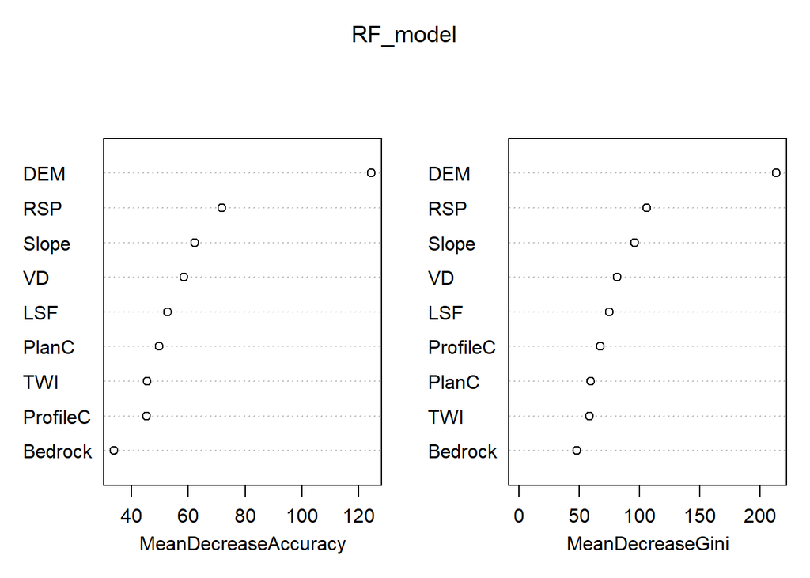

```r
sampleNum_dict[mn]<-nrow(sampData)

sampData$Bedrock<- droplevels(as.factor(sampData$Bedrock))
sampData$soilID<- droplevels(as.factor(sampData$soilID))

RF_model<-randomForest(soilID ~.,data = sampData,
                       importance = TRUE, proximity = FALSE,
                       ntree=1000,type="classification")

varImpPlot(RF_model)
```

```r
print(RF_model)
```

```
##
## Call:
##  randomForest(formula = soilID ~ ., data = sampData, importance = TRUE,      proximity = FALSE, ntree = 1000, type = "classification")
##                Type of random forest: classification
##                      Number of trees: 1000
## No. of variables tried at each split: 3
##
##         OOB estimate of  error rate: 28.96%
## Confusion matrix:
##     1 20 21 23  3 30 31 501 502 503   7 class.error
## 1   2  0  0  0  2  0  0   0   0   0   0   0.5000000
## 20  0 63 11  0  0  0  0   2   0  25  19   0.4750000
## 21  0 19 22  0  0  0  0   2   0   2   0   0.5111111
## 23  0  0  0 43  0  7  5   0   0  23   2   0.4625000
## 3   0  0  0  0 35  0  0  19   0   0   0   0.3518519
## 30  0  0  0 14  0  4  1   0   0   1   1   0.8095238
## 31  0  0  0  6  0  0 31   0   0   3   0   0.2250000
## 501 0  2  0  0 12  0  0 166   0   0  10   0.1263158
## 502 0  4  2  0  0  0  0   5   5   0   4   0.7500000
## 503 0 21  0 10  0  1  0   0   2 192   6   0.1724138
## 7   0 10  0  3  0  1  0  11   0   8 114   0.2244898
```

```r
map_RF <- predict(covStack, RF_model, paste(result_tif_folder,mn,".tif",sep=""),
                  format = "GTiff", datatype = "FLT4S", overwrite = TRUE)

rm("mn","shpPoint","sampData","RF_model","map_RF")
```

## ns7

RANst PlanC ns7 15

```r
mn="All_pRANst_PlanC_NS7_pen15"

shpPoint<-readOGR(paste(point_shp_folder,mn,".shp",sep = "")) ###
sampData <- extract(covStack, shpPoint, sp = TRUE,method = "simple")

sampData<-sampData@data

sampData<-sampData[sampData$soilID %in% soil_type,]

sampData<-na.omit(sampData)

print(dim(sampData))
```

```
## [1] 129  10
```

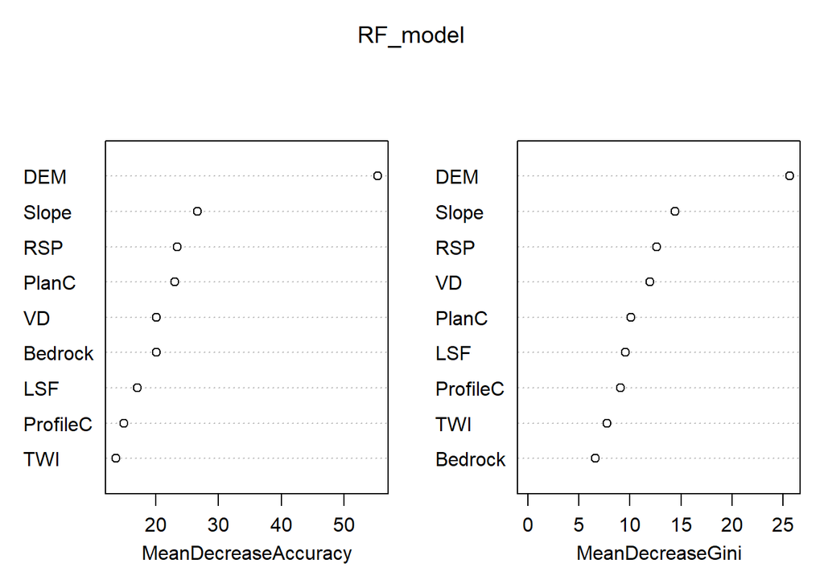

```r
sampleNum_dict[mn]<-nrow(sampData)

sampData$Bedrock<- droplevels(as.factor(sampData$Bedrock))
sampData$soilID<- droplevels(as.factor(sampData$soilID))

RF_model<-randomForest(soilID ~.,data = sampData,
                       importance = TRUE, proximity = FALSE,
                       ntree=1000,type="classification")

varImpPlot(RF_model)
```

```r
print(RF_model)
```

```
##
## Call:
##  randomForest(formula = soilID ~ ., data = sampData, importance = TRUE,      proximity = FALSE, ntree = 1000, type = "classification")
##                Type of random forest: classification
##                      Number of trees: 1000
## No. of variables tried at each split: 3
##
##         OOB estimate of  error rate: 34.11%
## Confusion matrix:
##     1 20 21 23 3 30 31 501 502 503  7 class.error
## 1   0  0  0  0 1  0  0   0   0   0  0   1.0000000
## 20  0 11  2  0 0  0  0   0   0   4  1   0.3888889
## 21  0  3  0  0 0  0  0   0   0   0  1   1.0000000
## 23  0  0  0  5 0  0  1   0   0   4  0   0.5000000
## 3   0  0  0  0 4  0  0   3   0   0  0   0.4285714
## 30  0  0  0  2 0  0  0   0   0   0  0   1.0000000
## 31  0  0  0  0 0  0  3   0   0   1  0   0.2500000
## 501 0  0  0  0 1  0  0  22   0   0  2   0.1200000
## 502 0  0  0  0 0  0  0   2   1   0  1   0.7500000
## 503 0  2  1  2 0  0  0   0   0  23  3   0.2580645
## 7   0  1  2  0 0  0  0   1   0   3 16   0.3043478
```

```r
map_RF <- predict(covStack, RF_model, paste(result_tif_folder,mn,".tif",sep=""),
                  format = "GTiff", datatype = "FLT4S", overwrite = TRUE)

rm("mn","shpPoint","sampData","RF_model","map_RF")
```

RANst PlanC ns7 30

```r
mn="All_pRANst_PlanC_NS7_pen30"

shpPoint<-readOGR(paste(point_shp_folder,mn,".shp",sep = "")) ###
sampData <- extract(covStack, shpPoint, sp = TRUE,method = "simple")

sampData<-sampData@data

sampData<-sampData[sampData$soilID %in% soil_type,]

sampData<-na.omit(sampData)

print(dim(sampData))
```

```
## [1] 227  10
```

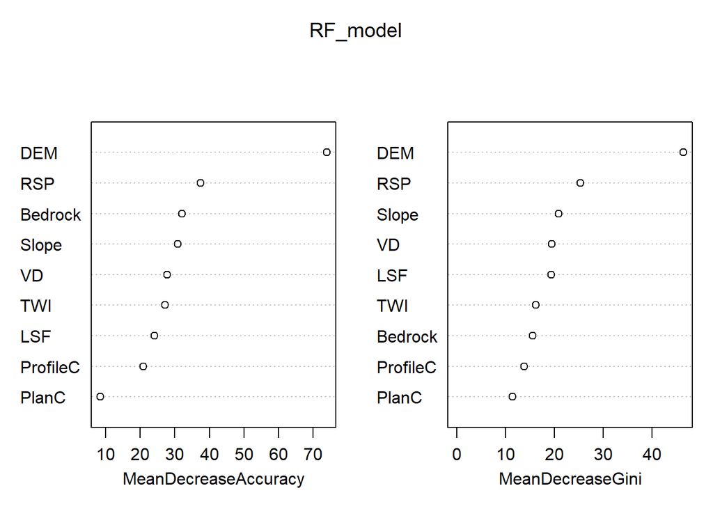

```r
sampleNum_dict[mn]<-nrow(sampData)

sampData$Bedrock<- droplevels(as.factor(sampData$Bedrock))
sampData$soilID<- droplevels(as.factor(sampData$soilID))

RF_model<-randomForest(soilID ~.,data = sampData,
                       importance = TRUE, proximity = FALSE,
                       ntree=1000,type="classification")

varImpPlot(RF_model)
```

```r
print(RF_model)
```

```
##
## Call:
##  randomForest(formula = soilID ~ ., data = sampData, importance = TRUE,      proximity = FALSE, ntree = 1000, type = "classification")
##                Type of random forest: classification
##                      Number of trees: 1000
## No. of variables tried at each split: 3
##
##         OOB estimate of  error rate: 34.36%
## Confusion matrix:
##     1 20 21 23 3 30 31 501 502 503  7 class.error
## 1   0  0  0  0 1  0  0   0   0   0  0  1.00000000
## 20  0 15  5  1 0  0  0   0   0   3  4  0.46428571
## 21  0  4  1  0 0  0  0   0   0   0  0  0.80000000
## 23  0  0  0  8 0  0  3   0   0   7  1  0.57894737
## 3   0  0  0  0 6  0  0   7   0   0  0  0.53846154
## 30  0  0  0  1 0  0  2   0   0   0  0  1.00000000
## 31  0  0  0  3 0  0  4   0   0   0  0  0.42857143
## 501 0  0  0  0 1  0  0  45   0   0  3  0.08163265
## 502 0  0  0  0 0  0  0   2   0   2  2  1.00000000
## 503 0  5  0  3 0  0  0   0   2  45  2  0.21052632
## 7   0  2  0  2 0  0  0   5   0   5 25  0.35897436
```

```r
map_RF <- predict(covStack, RF_model, paste(result_tif_folder,mn,".tif",sep=""),
                  format = "GTiff", datatype = "FLT4S", overwrite = TRUE)

rm("mn","shpPoint","sampData","RF_model","map_RF")
```

RANst PlanC ns7 45

```r
mn="All_pRANst_PlanC_NS7_pen45"

shpPoint<-readOGR(paste(point_shp_folder,mn,".shp",sep = "")) ###
sampData <- extract(covStack, shpPoint, sp = TRUE,method = "simple")

sampData<-sampData@data

sampData<-sampData[sampData$soilID %in% soil_type,]

sampData<-na.omit(sampData)

print(dim(sampData))
```

```
## [1] 320  10
```

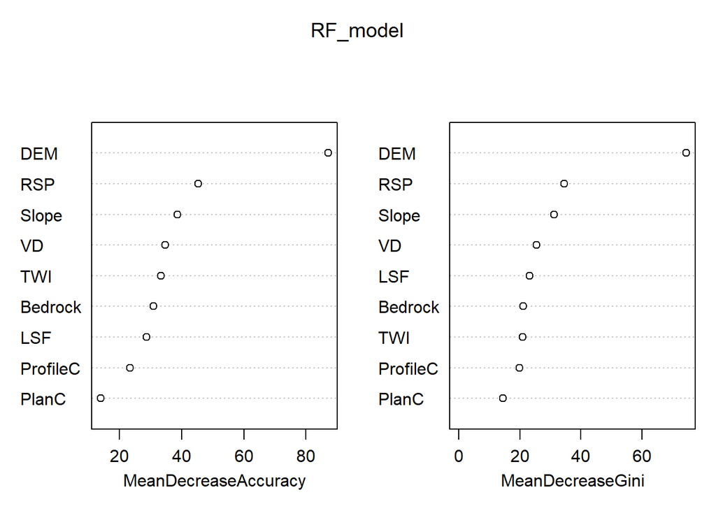

```r
sampleNum_dict[mn]<-nrow(sampData)

sampData$Bedrock<- droplevels(as.factor(sampData$Bedrock))
sampData$soilID<- droplevels(as.factor(sampData$soilID))

RF_model<-randomForest(soilID ~.,data = sampData,
                       importance = TRUE, proximity = FALSE,
                       ntree=1000,type="classification")

varImpPlot(RF_model)
```

```r
print(RF_model)
```

```
##
## Call:
##  randomForest(formula = soilID ~ ., data = sampData, importance = TRUE,      proximity = FALSE, ntree = 1000, type = "classification")
##                Type of random forest: classification
##                      Number of trees: 1000
## No. of variables tried at each split: 3
##
##         OOB estimate of  error rate: 30%
## Confusion matrix:
##     1 20 21 23 3 30 31 501 502 503  7 class.error
## 1   1  0  0  0 1  0  0   0   0   0  0   0.5000000
## 20  0 16  3  0 0  0  0   1   0   9  6   0.5428571
## 21  0  3  3  0 0  0  0   0   0   2  0   0.6250000
## 23  0  0  0 15 0  0  1   0   0   8  2   0.4230769
## 3   0  0  0  0 9  0  0  10   0   0  0   0.5263158
## 30  0  0  0  1 0  0  2   0   0   1  0   1.0000000
## 31  0  0  0  2 0  0  9   0   0   0  0   0.1818182
## 501 0  0  0  0 5  0  0  64   0   0  4   0.1232877
## 502 0  0  0  0 0  0  0   5   2   0  1   0.7500000
## 503 0  8  0  4 0  0  0   0   0  64  5   0.2098765
## 7   0  3  0  0 0  0  0   3   0   6 41   0.2264151
```

```r
map_RF <- predict(covStack, RF_model, paste(result_tif_folder,mn,".tif",sep=""),
                  format = "GTiff", datatype = "FLT4S", overwrite = TRUE)

rm("mn","shpPoint","sampData","RF_model","map_RF")
```

# ProfileC -ok

## ns3

RANst ProfileC ns3 15

```r
mn="All_pRANst_ProfileC_NS3_pen15"

shpPoint<-readOGR(paste(point_shp_folder,mn,".shp",sep = "")) ###
sampData <- extract(covStack, shpPoint, sp = TRUE,method = "simple")

sampData<-sampData@data

sampData<-sampData[sampData$soilID %in% soil_type,]

sampData<-na.omit(sampData)

print(dim(sampData))
```

```
## [1] 998  10
```

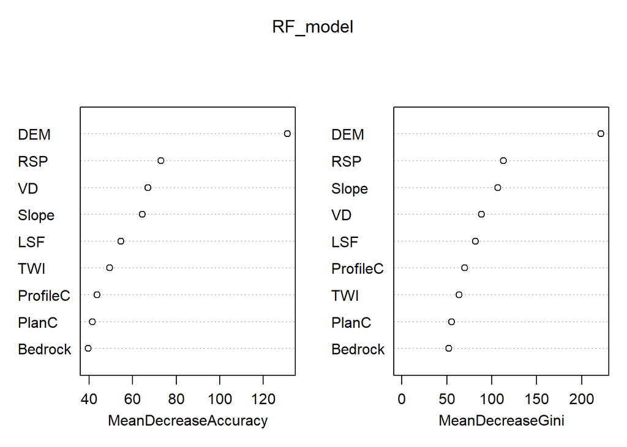

```r
sampleNum_dict[mn]<-nrow(sampData)

sampData$Bedrock<- droplevels(as.factor(sampData$Bedrock))
sampData$soilID<- droplevels(as.factor(sampData$soilID))

RF_model<-randomForest(soilID ~.,data = sampData,
                       importance = TRUE, proximity = FALSE,
                       ntree=1000,type="classification")

varImpPlot(RF_model)
```

```r
print(RF_model)
```

```
##
## Call:
##  randomForest(formula = soilID ~ ., data = sampData, importance = TRUE,      proximity = FALSE, ntree = 1000, type = "classification")
##                Type of random forest: classification
##                      Number of trees: 1000
## No. of variables tried at each split: 3
##
##         OOB estimate of  error rate: 28.26%
## Confusion matrix:
##     1 20 21 23  3 30 31 501 502 503   7 class.error
## 1   3  0  0  0  2  0  0   0   0   0   0  0.40000000
## 20  0 93 14  0  0  0  0   1   1  31  16  0.40384615
## 21  0 26 25  0  0  0  0   1   0   4   1  0.56140351
## 23  0  0  0 64  0  7  5   0   0  16   5  0.34020619
## 3   1  0  0  0 38  0  0  14   0   0   0  0.28301887
## 30  0  0  0  8  0 18  3   0   0   1   3  0.45454545
## 31  0  0  0  9  0  7 22   0   0   1   0  0.43589744
## 501 0  0  0  0  8  0  0 147   0   0   6  0.08695652
## 502 0  5  0  0  0  0  0   2   8   0   6  0.61904762
## 503 0 22  1 16  0  1  0   0   0 188   5  0.19313305
## 7   0  8  0  2  0  2  0   9   1  11 110  0.23076923
```

```r
map_RF <- predict(covStack, RF_model, paste(result_tif_folder,mn,".tif",sep=""),
                  format = "GTiff", datatype = "FLT4S", overwrite = TRUE)

rm("mn","shpPoint","sampData","RF_model","map_RF")
```

RANst ProfileC ns3 30

```r
mn="All_pRANst_ProfileC_NS3_pen30"

shpPoint<-readOGR(paste(point_shp_folder,mn,".shp",sep = "")) ###
sampData <- extract(covStack, shpPoint, sp = TRUE,method = "simple")

sampData<-sampData@data

sampData<-sampData[sampData$soilID %in% soil_type,]

sampData<-na.omit(sampData)

print(dim(sampData))
```

```
## [1] 1948   10
```

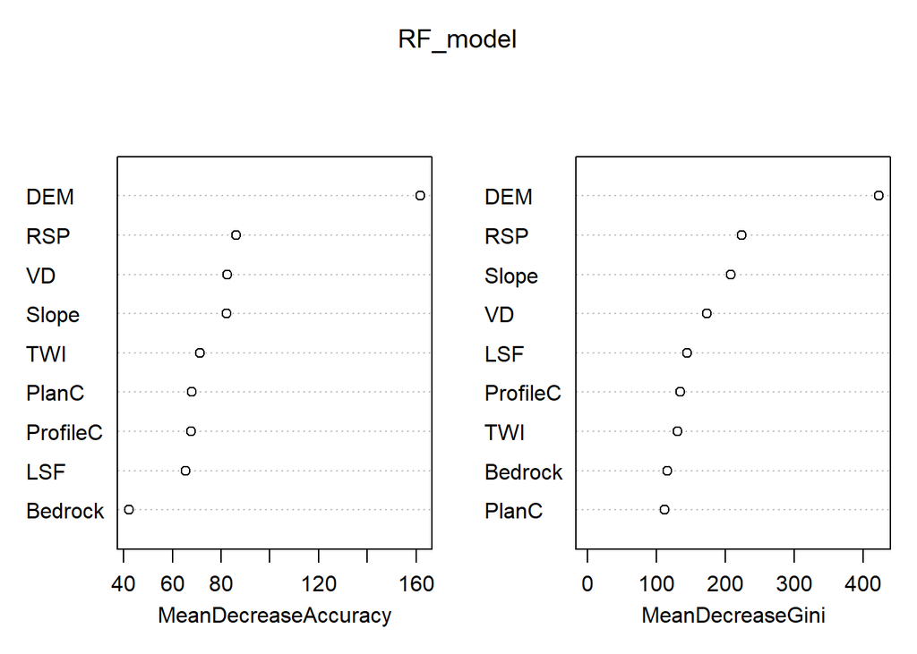

```r
sampleNum_dict[mn]<-nrow(sampData)

sampData$Bedrock<- droplevels(as.factor(sampData$Bedrock))
sampData$soilID<- droplevels(as.factor(sampData$soilID))

RF_model<-randomForest(soilID ~.,data = sampData,
                       importance = TRUE, proximity = FALSE,
                       ntree=1000,type="classification")

varImpPlot(RF_model)
```

```r
print(RF_model)
```

```
##
## Call:
##  randomForest(formula = soilID ~ ., data = sampData, importance = TRUE,      proximity = FALSE, ntree = 1000, type = "classification")
##                Type of random forest: classification
##                      Number of trees: 1000
## No. of variables tried at each split: 3
##
##         OOB estimate of  error rate: 24.64%
## Confusion matrix:
##     1  20 21  23  3 30 31 501 502 503   7 class.error
## 1   7   0  0   0  3  0  0   0   0   0   0   0.3000000
## 20  0 194 25   0  0  0  0   6   1  49  28   0.3597360
## 21  0  49 49   0  0  0  0   1   3   4   2   0.5462963
## 23  0   0  0 132  0  9  6   0   0  29  10   0.2903226
## 3   2   0  0   0 77  0  0  26   0   0   0   0.2666667
## 30  0   0  0  17  0 32  6   0   0   2   5   0.4838710
## 31  0   0  0   8  0  5 64   0   0   1   0   0.1794872
## 501 0   3  0   0 21  0  0 287   0   0  10   0.1059190
## 502 0   2  2   0  1  0  0   0  31   0   4   0.2250000
## 503 0  43  5  27  0  1  0   0   0 373   9   0.1855895
## 7   0  20  1   2  0  5  0  13   1  13 222   0.1985560
```

```r
map_RF <- predict(covStack, RF_model, paste(result_tif_folder,mn,".tif",sep=""),
                  format = "GTiff", datatype = "FLT4S", overwrite = TRUE)

rm("mn","shpPoint","sampData","RF_model","map_RF")
```

RANst ProfileC ns3 45

```r
mn="All_pRANst_ProfileC_NS3_pen45"

shpPoint<-readOGR(paste(point_shp_folder,mn,".shp",sep = "")) ###
sampData <- extract(covStack, shpPoint, sp = TRUE,method = "simple")

sampData<-sampData@data

sampData<-sampData[sampData$soilID %in% soil_type,]

sampData<-na.omit(sampData)

print(dim(sampData))
```

```
## [1] 2897   10
```

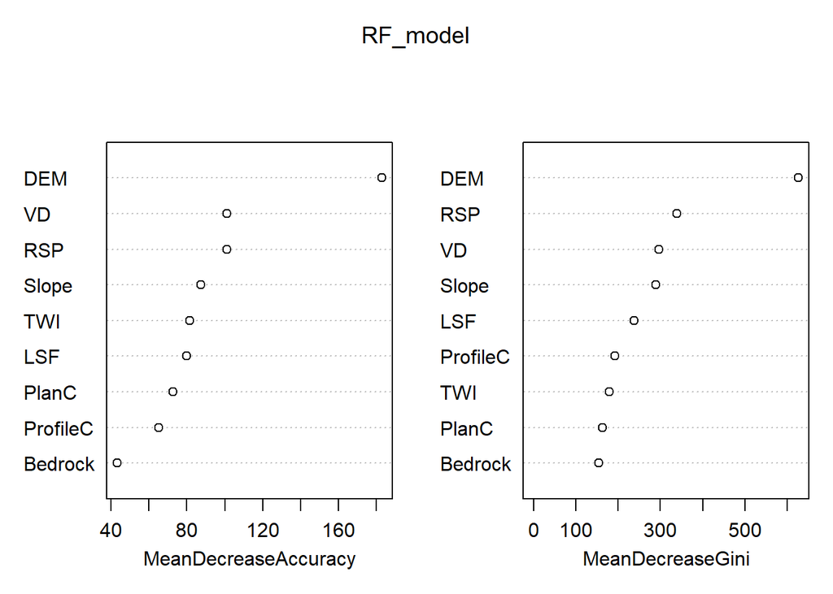

```r
sampleNum_dict[mn]<-nrow(sampData)

sampData$Bedrock<- droplevels(as.factor(sampData$Bedrock))
sampData$soilID<- droplevels(as.factor(sampData$soilID))

RF_model<-randomForest(soilID ~.,data = sampData,
                       importance = TRUE, proximity = FALSE,
                       ntree=1000,type="classification")

varImpPlot(RF_model)
```

```r
print(RF_model)
```

```
##
## Call:
##  randomForest(formula = soilID ~ ., data = sampData, importance = TRUE,      proximity = FALSE, ntree = 1000, type = "classification")
##                Type of random forest: classification
##                      Number of trees: 1000
## No. of variables tried at each split: 3
##
##         OOB estimate of  error rate: 25.03%
## Confusion matrix:
##      1  20 21  23   3 30 31 501 502 503   7 class.error
## 1   11   0  0   0   4  0  0   0   0   0   0   0.2666667
## 20   0 295 38   2   0  0  0   8   3  66  37   0.3429844
## 21   0  62 80   0   0  0  0   0   2  13   3   0.5000000
## 23   0   0  0 189   0 15  9   0   0  49  12   0.3102190
## 3    0   0  0   0 116  0  0  41   0   0   0   0.2611465
## 30   0   0  0  16   0 55  5   0   0   4  11   0.3956044
## 31   0   0  0  18   0  8 89   0   0   2   0   0.2393162
## 501  0   2  0   0  31  0  0 431   0   0  17   0.1039501
## 502  0   6  3   0   0  0  0   0  43   0   5   0.2456140
## 503  0  55  9  44   0  3  0   0   0 549  25   0.1985401
## 7    0  36  1   1   0  4  0  30   4  21 314   0.2360097
```

```r
map_RF <- predict(covStack, RF_model, paste(result_tif_folder,mn,".tif",sep=""),
                  format = "GTiff", datatype = "FLT4S", overwrite = TRUE)

rm("mn","shpPoint","sampData","RF_model","map_RF")
```